# Обзор бизнес-показателей маркетплейса

Маркетплейс находится в стадии активного роста и уже вышел на уровень устойчивой монетизации. Однако до настоящего момента продукт развивался преимущественно на основе бухгалтерских отчётов и интуитивных решений, без системной продуктовой аналитики. С ростом бизнеса появилась необходимость глубже понимать поведение пользователей, источники роста, эффективность маркетинговых каналов и вклад отдельных категорий товаров в выручку. Выручка маркетплейса формируется в виде комиссии в размере 5% от стоимости каждой продажи.

В рамках данного аттестационного проекта проводится комплексный анализ продуктовых и бизнес-показателей маркетплейса: от привлечения и активации пользователей до монетизации и возврата инвестиций.

### Цель проекта

Необходимо провести комплексный анализ пользовательского поведения и ключевых бизнес-метрик маркетплейса, оценить эффективность монетизации и маркетинговых затрат, выявить инсайты и точки роста, а также подготовить основу для продуктовых гипотез и экспериментов.

### Задачи проекта

Для достижения цели в рамках проекта необходимо:

1. Первичный анализ и сбор данных.
2. Обзор ключевых метрик.
3. Оценка метрик монетизации и юнит-экономики.
4. Поиск инсайтов и точек роста. Сегментация и формулирование гипотез.
5. Подготовка эксперимента и подведение его итогов.

### Описание данных

В проекте используются данные маркетплейса, хранящиеся по ссылкам ниже:

`https://code.s3.yandex.net/datasets/pa_marketplace_orders.csv` `https://code.s3.yandex.net/datasets/pa_marketplace_campaign_costs.csv` `https://code.s3.yandex.net/datasets/pa_marketplace_users.csv`  
`https://code.s3.yandex.net/datasets/pa_marketplace_events.csv`

**Таблица `Users`**

| Поле | Описание |
| --- | --- |
| `user_id` | Уникальный идентификатор пользователя. |
| `registration_date` | Дата регистрации пользователя. |
| `age` | Возраст пользователя. |
| `gender` | Пол. |
| `region` | Регион. |
| `acq_channel` | Канал привлечения. |
| `buyer_segment` | Сегмент покупателя. |
| `cohort_week` | Неделя привлечения. |
| `cohort_month` | Месяц привлечения. |

**Таблица `Events`**

| Поле | Описание |
| --- | --- |
| `event_id` | Уникальный идентификатор события. |
| `user_id` | Идентификатор пользователя. |
| `event_date` | Дата события. |
| `event_type` | Тип события. |
| `os` | Операционная система. |
| `device` | Тип устройства. |
| `product_name` | Наименование товара, к которому относится событие (если применимо). |
| `event_week` | Неделя события. |
| `event_month` | Месяц события . |

**Таблица `Orders`**

| Поле | Описание |
| --- | --- |
| `order_id` | Уникальный идентификатор заказа. |
| `user_id` | Идентификатор пользователя, который сделал заказ |
| `order_date` | Дата и время оформления заказа. |
| `product_name` | Наименование товара. |
| `quantity` | Количество единиц товара в заказе. |
| `unit_price` | Цена за одну единицу товара. |
| `total_price` | Итоговая сумма заказа. |
| `category_name` | Наименование категории товара. |
| `order_week` | Неделя заказа. |
| `order_month` | Месяц заказа. |

**Таблица `Campaign_costs`**

| Поле | Описание |
| --- | --- |
| `acq_channel` | Канал привлечения. |
| `spend_month` | Месяц, в который был потрачен бюджет (отражает период, в котором были привлечены пользователи) |
| `budget` | Маркетинговый бюджет (в денежном выражении), потраченный на данный канал в указанном месяце. |

**Описание событий**

| Событие | Описание |
| --- | --- |
| `page_view` | Открытие любой страницы сайта или приложения пользователем. |
| `product_view` | Просмотр страницы конкретного товара. |
| `product_click` | Клик по товару (например, из списка товаров или на баннере). |
| `add_to_cart` | Добавление товара в корзину. |
| `remove_from_cart` | Удаление товара из корзины. |
| `search` | Выполнение поиска по сайту или приложению. |
| `filter_apply` | Применение фильтра (например, по цене, бренду, категории). |
| `checkout_start` | Начало оформления заказа (переход к оформлению корзины). |
| `checkout_complete` | Завершение оформления заказа (не гарантирует покупку, покупка зависит от факта оплаты). |
| `user_login` | Вход пользователя в личный кабинет или аккаунт. |
| `user_logout` | Выход пользователя из аккаунта. |
| `wishlist_add` | Добавление товара в список желаемого (wishlist). |
| `category_view` | Просмотр страницы категории товаров. |
| `banner_click` | Клик по рекламному баннеру на сайте или в приложении. |
| `promo_view` | Просмотр промо-акции или специального предложения. |

## Содержимое проекта

- 1 Первичный анализ и сбор данных
- 2 Обзор ключевых метрик
  - 2.1 Эффективность монетизации
  - 2.2 Активность и лояльность аудитории
  - 2.3 Юнит-экономика и маркетинг
- 3 Текущее состояние продукта и ключевые риски
- 4 Поиск инсайтов, точек роста и сегментация
  - 4.1 Анализ по каналам привлечения
  - 4.2 Сегментация по типу пользователей
    - 4.2.1 Анализ новых пользователей и возвращающихся
    - 4.2.2 Анализ пользователей по частоте покупок
  - 4.3 Сегментация по устройствам
  - 4.4 Анализ регионов
  - 4.5 Анализ воронки
  - 4.6 Категории товаров
  - 4.7 Ключевые результаты анализа
- 5 Подготовка эксперимента и подведение его результатов
  - 5.1 Анализ аудитории эксперимента
  - 5.2 Сравнение воронок событий
  - 5.3 Анализ метрик А/В-эксперимента
  - 5.4 Ключевые выводы А/В-эксперимента

## 1 Первичный анализ и сбор данных

Загрузим данные из четырех датасетов и получим основную информацию о них. Проведем предобработку. Зафиксируем основную информацию о данных и предобработке в кратком промежуточном выводе.

```python
# Импортируем библиотеки для работы с данными и визуализациями
import pandas as pd
import matplotlib.pyplot as plt
import matplotlib.colors as mcolors
import seaborn as sns
import numpy as np
from scipy.stats import mannwhitneyu
from statsmodels.stats.proportion import proportions_ztest
```

- Загрузим и рассмотрим **данные о пользователях.**

```python
# Выгружаем данные о пользователях
pa_marketplace_users = pd.read_csv('https://code.s3.yandex.net/datasets/pa_marketplace_users.csv',
                                  parse_dates=['registration_date', 'cohort_week', 'cohort_month'])

display(pa_marketplace_users.head())
print()
pa_marketplace_users.info()
```

|  | user_id | registration_date | age | gender | region | acq_channel | buyer_segment | cohort_week | cohort_month |
| --- | --- | --- | --- | --- | --- | --- | --- | --- | --- |
| 0 | 1 | 2024-01-01 00:47:00 | 35 | M | Москва | Google Ads | regular | 2024-01-01 | 2024-01-01 |
| 1 | 2 | 2024-01-01 19:01:00 | 53 | M | Москва | Email Marketing | rare | 2024-01-01 | 2024-01-01 |
| 2 | 3 | 2024-01-01 04:13:00 | 66 | F | Санкт-Петербург | Google Ads | regular | 2024-01-01 | 2024-01-01 |
| 3 | 4 | 2024-01-01 17:18:00 | 58 | M | Краснодар | Affiliate | one_time | 2024-01-01 | 2024-01-01 |
| 4 | 5 | 2024-01-01 08:29:00 | 58 | F | Другие регионы | Google Ads | regular | 2024-01-01 | 2024-01-01 |

```
<class 'pandas.core.frame.DataFrame'>
RangeIndex: 44151 entries, 0 to 44150
Data columns (total 9 columns):
 #   Column             Non-Null Count  Dtype
---  ------             --------------  -----
 0   user_id            44151 non-null  int64
 1   registration_date  44151 non-null  datetime64[ns]
 2   age                44151 non-null  int64
 3   gender             44151 non-null  object
 4   region             44151 non-null  object
 5   acq_channel        44151 non-null  object
 6   buyer_segment      44151 non-null  object
 7   cohort_week        44151 non-null  datetime64[ns]
 8   cohort_month       44151 non-null  datetime64[ns]
dtypes: datetime64[ns](3), int64(2), object(4)
memory usage: 3.0+ MB
```

Данные представлены корректными типами данных.

- Посмотрим какое количество уникальных пользователей и какие регионы, каналы привлечения и сегменты покупателей представлены в датасете.

```python
# Выводим количество уникальных значений в колонке user_id и значения в region, acq_channel, buyer_segment
print(f"Количество уникальных значений user_id - {pa_marketplace_users['user_id'].nunique()}.")

summary_users = (
    pa_marketplace_users[['region', 'acq_channel','buyer_segment']]
    .apply(lambda x: ", ".join(sorted(x.dropna().unique())))
    .reset_index()
)

summary_users.columns = ['column', 'unique_values']
pd.set_option('display.max_colwidth', None)
display(summary_users)
```

```
Количество уникальных значений user_id - 44151.
```

|  | column | unique_values |
| --- | --- | --- |
| 0 | region | Другие регионы, Екатеринбург, Краснодар, Москва, Московская область, Нижний Новгород, Новосибирск, Ростов-на-Дону, Санкт-Петербург |
| 1 | acq_channel | Affiliate, Email Marketing, Google Ads, SEO, Social Media, TikTok |
| 2 | buyer_segment | medium, one_time, rare, regular |

В датасете представлен 44 151 уникальный пользователь и все ключевые признаки: регион, канал привлечения и сегмент покупателей.

- Проверим интервал дат регистрации пользователей.

```python
# Проверим интервал дат регистраций
start_date = pa_marketplace_users['registration_date'].min()
end_date = pa_marketplace_users['registration_date'].max()

print(f'Период данных: с {start_date} по {end_date}')
```

```
Период данных: с 2024-01-01 00:07:00 по 2024-12-31 23:44:00
```

- Проверим данные на наличие дубликатов.

```python
# Количество полных дубликатов
full_duplicates = pa_marketplace_users.duplicated().sum()
print(f'Количество полных дубликатов строк: {full_duplicates}')
```

```
Количество полных дубликатов строк: 0
```

```python
# Проверим дубликаты по комбинации ключевых полей
key_duplicates = (
    pa_marketplace_users
    .duplicated(subset=['user_id', 'registration_date', 'acq_channel'])
    .sum()
)

print(f'Неявные дубликаты событий: {key_duplicates}')
```

```
Неявные дубликаты событий: 0
```

В рамках этапа предобработки были загружены исторические данные о пользователях, зарегестрированных в период 2024 года.

Датасет `pa_marketplace_users` содержит 9 столбцов и 44 151 строку с данными.

После первичного анализа данных можно сделать следующие выводы:

- Большинство столбцов представлены корректными типами данных.
- Столбцы `registration_date`, `cohort_week`, `cohort_month` успешно преобразованы в формат `datetime`, что позволяет анализировать пользовательское поведение во времени.
- Пропусков в данных нет.
- В датасете представлен 44 151 уникальный зарегистрированный пользователь (`user_id`).
- Полные дубликаты строк отсутствуют.
- Неявные дубликаты событий не выявлены.

Данные имеют хорошее качество и не содержат критических ошибок, пропусков или дубликатов. Датасет полностью готов для дальнейшего анализа.

- Загрузим и рассмотрим **данные о событиях пользователей.**

```python
# Выгружаем данные о событиях пользователей
pa_marketplace_events = pd.read_csv('https://code.s3.yandex.net/datasets/pa_marketplace_events.csv',
                                  parse_dates=['event_date', 'event_week', 'event_month'])

display(pa_marketplace_events.head())
print()
pa_marketplace_events.info()
```

|  | event_id | user_id | event_date | event_type | os | device | product_name | event_week | event_month |
| --- | --- | --- | --- | --- | --- | --- | --- | --- | --- |
| 0 | 3132 | 100 | 2024-01-01 | page_view | iOS | mobile | NaN | 2024-01-01 | 2024-01-01 |
| 1 | 3133 | 100 | 2024-01-01 | product_view | iOS | mobile | Шорты для тренировок | 2024-01-01 | 2024-01-01 |
| 2 | 3134 | 100 | 2024-01-01 | product_click | iOS | mobile | Куртка детская | 2024-01-01 | 2024-01-01 |
| 3 | 3135 | 100 | 2024-01-01 | add_to_cart | iOS | mobile | Балетки классические | 2024-01-01 | 2024-01-01 |
| 4 | 3136 | 100 | 2024-01-01 | checkout_start | iOS | mobile | NaN | 2024-01-01 | 2024-01-01 |

```
<class 'pandas.core.frame.DataFrame'>
RangeIndex: 785859 entries, 0 to 785858
Data columns (total 9 columns):
 #   Column        Non-Null Count   Dtype
---  ------        --------------   -----
 0   event_id      785859 non-null  int64
 1   user_id       785859 non-null  int64
 2   event_date    785859 non-null  datetime64[ns]
 3   event_type    785859 non-null  object
 4   os            785859 non-null  object
 5   device        785859 non-null  object
 6   product_name  385740 non-null  object
 7   event_week    785859 non-null  datetime64[ns]
 8   event_month   785859 non-null  datetime64[ns]
dtypes: datetime64[ns](3), int64(2), object(4)
memory usage: 54.0+ MB
```

Данные представлены корректными типами данных.

- Посмотрим какое количество уникальных событий, пользователей и названий продуктов, а также какие типы события, операционные системы, типы устройства и наименования товара, к которому относится событие, представлены в датасете.

```python
# Выводим количество уникальных значений в колонке event_id, user_id, product_name и значения в event_type, os, device
print(f"Количество уникальных значений event_id - {pa_marketplace_events['event_id'].nunique()}.")
print(f"Количество уникальных значений user_id - {pa_marketplace_events['user_id'].nunique()}.")
print(f"Количество уникальных значений product_name - {pa_marketplace_events['product_name'].nunique()}.")

summary_events = (
    pa_marketplace_events[['event_type', 'os', 'device']]
    .apply(lambda x: ", ".join(sorted(x.dropna().unique())))
    .reset_index()
)

summary_events.columns = ['column', 'unique_values']
pd.set_option('display.max_colwidth', None)
display(summary_events)
```

```
Количество уникальных значений event_id - 785859.
Количество уникальных значений user_id - 22138.
Количество уникальных значений product_name - 200.
```

|  | column | unique_values |
| --- | --- | --- |
| 0 | event_type | add_to_cart, banner_click, category_view, checkout_complete, checkout_start, filter_apply, page_view, product_click, product_view, promo_view, remove_from_cart, search, user_login, user_logout, wishli… |
| 1 | os | Android, Windows, iOS, macOS |
| 2 | device | desktop, mobile, tablet |

- Проверим интервал дат событий пользователей.

```python
# Проверим интервал дат событий
start_date_events = pa_marketplace_events['event_date'].min()
end_date_events = pa_marketplace_events['event_date'].max()

print(f'Период данных: с {start_date_events} по {end_date_events}')
```

```
Период данных: с 2024-01-01 00:00:00 по 2024-12-31 00:00:00
```

- Проверим данные на наличие дубликатов.

```python
# Количество полных дубликатов
full_duplicates_events = pa_marketplace_events.duplicated().sum()
print(f'Количество полных дубликатов строк: {full_duplicates_events}')
```

```
Количество полных дубликатов строк: 0
```

```python
# Проверим дубликаты по комбинации ключевых полей
key_duplicates_events = (
    pa_marketplace_events
    .duplicated(subset=['user_id', 'event_date', 'event_type', 'os', 'device', 'product_name'])
    .sum()
)

print(f'Неявные дубликаты событий: {key_duplicates_events}')
```

```
Неявные дубликаты событий: 122230
```

```python
# Выгрузим строки с неявными дубликатами по ключевым полям
duplicate_events_rows = pa_marketplace_events[
    pa_marketplace_events.duplicated(
        subset=['user_id', 'event_date', 'event_type', 'os', 'device', 'product_name'],
        keep=False
    )
].sort_values(['user_id', 'event_date', 'event_type'])

display(duplicate_events_rows.head(10))
```

|  | event_id | user_id | event_date | event_type | os | device | product_name | event_week | event_month |
| --- | --- | --- | --- | --- | --- | --- | --- | --- | --- |
| 569 | 60 | 3 | 2024-01-05 | checkout_complete | Android | mobile | NaN | 2024-01-01 | 2024-01-01 |
| 570 | 72 | 3 | 2024-01-05 | checkout_complete | Android | mobile | NaN | 2024-01-01 | 2024-01-01 |
| 572 | 86 | 3 | 2024-01-05 | checkout_complete | Android | mobile | NaN | 2024-01-01 | 2024-01-01 |
| 573 | 66 | 3 | 2024-01-05 | checkout_complete | Android | mobile | NaN | 2024-01-01 | 2024-01-01 |
| 575 | 98 | 3 | 2024-01-05 | checkout_complete | Android | mobile | NaN | 2024-01-01 | 2024-01-01 |
| 576 | 117 | 3 | 2024-01-05 | checkout_complete | Android | mobile | NaN | 2024-01-01 | 2024-01-01 |
| 7078 | 80 | 3 | 2024-01-16 | checkout_complete | Android | mobile | NaN | 2024-01-15 | 2024-01-01 |
| 7079 | 104 | 3 | 2024-01-16 | checkout_complete | Android | mobile | NaN | 2024-01-15 | 2024-01-01 |
| 7081 | 47 | 3 | 2024-01-16 | checkout_complete | Android | mobile | NaN | 2024-01-15 | 2024-01-01 |
| 7082 | 92 | 3 | 2024-01-16 | checkout_complete | Android | mobile | NaN | 2024-01-15 | 2024-01-01 |

В рамках этапа предобработки были загружены исторические данные о пользователях, зарегестрированных в период 2024 года.

Датасет `pa_marketplace_events` содержит 9 столбцов и 785 859 строк с данными о взаимодействиях пользователей с продуктом.

После первичного анализа данных можно сделать следующие выводы:

- Большинство столбцов представлены корректными типами данных.
- Столбцы `event_date`, `event_week`, `event_month` успешно преобразованы в формат `datetime`, что позволяет анализировать пользовательское поведение во времени.
- Пропуски в столбце `product_name` соответствуют событиям, не привязанным к конкретному товару. Дополнительной обработки пропусков не требуется.
- В датасете представлено 785 859 уникальных событий (`event_id`) и 22 138 уникальных пользователей (`user_id`).
- Полные дубликаты строк отсутствуют.
- Неявные дубликаты (совпадение по `user_id`, `event_date`, `event_type`, `os`, `device`, `product_name`) выявлены в количестве 122 230 строк. Поскольку точного времени до секунд для событий нет, нельзя с полной уверенностью сказать, являются ли они повторными действиями пользователей или техническими дубликатами. При построении метрик следует учитывать эту неопределённость в зависимости от целей анализа.

Данные имеют хорошее качество и не содержат критических ошибок. Датасет полностью готов для дальнейшего анализа.

- Загрузим и рассмотрим **данные о заказах пользователей.**

```python
# Выгружаем данные о заказах пользователей
pa_marketplace_orders = pd.read_csv('https://code.s3.yandex.net/datasets/pa_marketplace_orders.csv',
                                  parse_dates=['order_date', 'order_week', 'order_month'])

display(pa_marketplace_orders.head())
print()
pa_marketplace_orders.info()
```

|  | order_id | user_id | order_date | product_name | quantity | unit_price | total_price | category_name | order_week | order_month |
| --- | --- | --- | --- | --- | --- | --- | --- | --- | --- | --- |
| 0 | 1 | 3 | 2024-01-19 01:52:52 | Шуруповерт | 2 | 5539.13 | 11078.26 | Инструменты и садовый инвентарь | 2024-01-15 | 2024-01-01 |
| 1 | 2 | 3 | 2024-01-19 01:52:52 | Молоток слесарный | 1 | 11340.38 | 11340.38 | Инструменты и садовый инвентарь | 2024-01-15 | 2024-01-01 |
| 2 | 3 | 3 | 2024-01-19 01:52:52 | Секатор садовый | 2 | 10892.09 | 21784.18 | Инструменты и садовый инвентарь | 2024-01-15 | 2024-01-01 |
| 3 | 4 | 3 | 2024-01-25 13:59:38 | Шуруповерт | 2 | 5539.13 | 11078.26 | Инструменты и садовый инвентарь | 2024-01-22 | 2024-01-01 |
| 4 | 5 | 3 | 2024-01-25 13:59:38 | Чай черный | 1 | 2099.59 | 2099.59 | Продукты питания | 2024-01-22 | 2024-01-01 |

```
<class 'pandas.core.frame.DataFrame'>
RangeIndex: 31357 entries, 0 to 31356
Data columns (total 10 columns):
 #   Column         Non-Null Count  Dtype
---  ------         --------------  -----
 0   order_id       31357 non-null  int64
 1   user_id        31357 non-null  int64
 2   order_date     31357 non-null  datetime64[ns]
 3   product_name   31357 non-null  object
 4   quantity       31357 non-null  int64
 5   unit_price     31357 non-null  float64
 6   total_price    31357 non-null  float64
 7   category_name  31357 non-null  object
 8   order_week     31357 non-null  datetime64[ns]
 9   order_month    31357 non-null  datetime64[ns]
dtypes: datetime64[ns](3), float64(2), int64(3), object(2)
memory usage: 2.4+ MB
```

Данные представлены корректными типами данных.

- Посмотрим какое количество уникальных событий, пользователей и названий продуктов, а также какие наименования категории товаров представлены в датасете.

```python
# Выводим количество уникальных значений в колонке event_id, user_id, product_name и значения в category_name
print(f"Количество уникальных значений order_id - {pa_marketplace_orders['order_id'].nunique()}.")
print(f"Количество уникальных значений user_id - {pa_marketplace_orders['user_id'].nunique()}.")
print(f"Количество уникальных значений product_name - {pa_marketplace_orders['product_name'].nunique()}.")
print(f"Количество уникальных значений category_name - {pa_marketplace_orders['category_name'].nunique()}.")
```

```
Количество уникальных значений order_id - 31357.
Количество уникальных значений user_id - 8922.
Количество уникальных значений product_name - 200.
Количество уникальных значений category_name - 25.
```

- Проверим интервал дат событий пользователей.

```python
# Проверим интервал дат событий
start_date_orders = pa_marketplace_orders['order_date'].min()
end_date_orders = pa_marketplace_orders['order_date'].max()

print(f'Период данных: с {start_date_orders} по {end_date_orders}')
```

```
Период данных: с 2024-01-01 08:03:45 по 2024-12-31 23:00:53
```

- Проверим данные на наличие дубликатов.

```python
# Количество полных дубликатов
full_duplicates_orders = pa_marketplace_orders.duplicated().sum()
print(f'Количество полных дубликатов строк: {full_duplicates_orders}')
```

```
Количество полных дубликатов строк: 0
```

```python
# Проверим дубликаты по комбинации ключевых полей
key_duplicates_orders = (
    pa_marketplace_orders
    .duplicated(subset=['user_id', 'order_date', 'product_name', 'quantity', 'unit_price', 'total_price'])
    .sum()
)

print(f'Неявные дубликаты событий: {key_duplicates_orders}')
```

```
Неявные дубликаты событий: 270
```

```python
# Выгрузим строки с неявными дубликатами по ключевым полям
duplicate_orders_rows = pa_marketplace_orders[
    pa_marketplace_orders.duplicated(
        subset=['user_id', 'order_date', 'product_name', 'quantity', 'unit_price', 'total_price'],
        keep=False
    )
].sort_values(['user_id', 'order_date'])

display(duplicate_orders_rows.head(10))
```

|  | order_id | user_id | order_date | product_name | quantity | unit_price | total_price | category_name | order_week | order_month |
| --- | --- | --- | --- | --- | --- | --- | --- | --- | --- | --- |
| 232 | 233 | 203 | 2024-02-07 22:19:44 | Тетрадь общая | 1 | 2829.81 | 2829.81 | Книги и канцтовары | 2024-02-05 | 2024-02-01 |
| 233 | 234 | 203 | 2024-02-07 22:19:44 | Тетрадь общая | 1 | 2829.81 | 2829.81 | Книги и канцтовары | 2024-02-05 | 2024-02-01 |
| 459 | 460 | 362 | 2024-01-26 02:59:13 | Свечи зажигания | 3 | 7696.64 | 23089.92 | Автотовары | 2024-01-22 | 2024-01-01 |
| 460 | 461 | 362 | 2024-01-26 02:59:13 | Свечи зажигания | 3 | 7696.64 | 23089.92 | Автотовары | 2024-01-22 | 2024-01-01 |
| 562 | 563 | 420 | 2024-01-13 19:39:50 | Чайник электрический | 3 | 6254.47 | 18763.41 | Товары для кухни | 2024-01-08 | 2024-01-01 |
| 563 | 564 | 420 | 2024-01-13 19:39:50 | Чайник электрический | 3 | 6254.47 | 18763.41 | Товары для кухни | 2024-01-08 | 2024-01-01 |
| 574 | 575 | 437 | 2024-01-08 06:02:49 | Футболка дышащая | 2 | 3114.57 | 6229.14 | Одежда для спорта | 2024-01-08 | 2024-01-01 |
| 575 | 576 | 437 | 2024-01-08 06:02:49 | Футболка дышащая | 2 | 3114.57 | 6229.14 | Одежда для спорта | 2024-01-08 | 2024-01-01 |
| 1022 | 1023 | 960 | 2024-02-08 21:42:49 | Консервы мясные | 2 | 2098.38 | 4196.76 | Продукты питания | 2024-02-05 | 2024-02-01 |
| 1023 | 1024 | 960 | 2024-02-08 21:42:49 | Консервы мясные | 2 | 2098.38 | 4196.76 | Продукты питания | 2024-02-05 | 2024-02-01 |

- Каждая пара дубликатов имеет одинаковое время в точности до секунд и одниковую стоимость в точности до копеек, что похоже на техническую ошибку при загрузке или синхронизации данных. Т.к. количество дубликатов меньше 1%, удалим эти дубликаты, чтобы они не искажали результаты.

```python
# Удалим дубликаты
pa_marketplace_orders_clean = (
    pa_marketplace_orders.drop_duplicates(
    subset=['user_id', 'order_date', 'product_name', 'quantity', 'unit_price', 'total_price']
))

print(f'Количество строк pa_marketplace_orders_clean {len(pa_marketplace_orders_clean)}')
```

```
Количество строк pa_marketplace_orders_clean 31087
```

В рамках этапа предобработки были загружены данные о заказах пользователей в период 2024 года.

Датасет `pa_marketplace_orders_clean` содержит 10 столбцов и 31 087 строк.

Данные имеют хорошее качество и не содержат критических ошибок. Датасет полностью готов для дальнейшего анализа.

- Загрузим и рассмотрим **данные о маркетинговых кампаниях.**

```python
# Выгружаем данные о маркетинговых кампаниях
pa_marketplace_campaign_costs = pd.read_csv('https://code.s3.yandex.net/datasets/pa_marketplace_campaign_costs.csv',
                                  parse_dates=['spend_month'])

display(pa_marketplace_campaign_costs.head())
print()
pa_marketplace_campaign_costs.info()
```

|  | Unnamed: 0 | acq_channel | spend_month | budget |
| --- | --- | --- | --- | --- |
| 0 | 0 | Affiliate | 2024-01-01 | 179343.3875 |
| 1 | 1 | Affiliate | 2024-02-01 | 175488.4875 |
| 2 | 2 | Affiliate | 2024-03-01 | 164543.4750 |
| 3 | 3 | Affiliate | 2024-04-01 | 186869.9750 |
| 4 | 4 | Affiliate | 2024-05-01 | 166443.7750 |

```
<class 'pandas.core.frame.DataFrame'>
RangeIndex: 88 entries, 0 to 87
Data columns (total 4 columns):
 #   Column       Non-Null Count  Dtype
---  ------       --------------  -----
 0   Unnamed: 0   88 non-null     int64
 1   acq_channel  88 non-null     object
 2   spend_month  88 non-null     datetime64[ns]
 3   budget       88 non-null     float64
dtypes: datetime64[ns](1), float64(1), int64(1), object(1)
memory usage: 2.9+ KB
```

Данные представлены корректными типами данных.

Столбец `Unnamed: 0` - служебный столбец, повторяющий индексы. Он не несет аналитической ценности и стоит его удалить.

```python
# Удаление служебного столбца
pa_marketplace_campaign_costs = pa_marketplace_campaign_costs.drop(columns=['Unnamed: 0'])

pa_marketplace_campaign_costs.info()
```

```
<class 'pandas.core.frame.DataFrame'>
RangeIndex: 88 entries, 0 to 87
Data columns (total 3 columns):
 #   Column       Non-Null Count  Dtype
---  ------       --------------  -----
 0   acq_channel  88 non-null     object
 1   spend_month  88 non-null     datetime64[ns]
 2   budget       88 non-null     float64
dtypes: datetime64[ns](1), float64(1), object(1)
memory usage: 2.2+ KB
```

- Посмотрим какие каналы привлечения представлены в датасете.

```python
# Выводим количество уникальных значений в колонке acq_channel
unique_channels = pa_marketplace_campaign_costs['acq_channel'].unique()

print("Уникальные каналы привлечения:\n- " + "\n- ".join(sorted(unique_channels)))
```

```
Уникальные каналы привлечения:
- Affiliate
- Direct
- Email Marketing
- Google Ads
- SEO
- Social Media
- TikTok
```

- Проверим интервал дат маркетинговых кампаний.

```python
# Проверим интервал дат событий
start_date_campaign = pa_marketplace_campaign_costs['spend_month'].min()
end_date_campaign = pa_marketplace_campaign_costs['spend_month'].max()

print(f'Период данных: с {start_date_campaign} по {end_date_campaign}')
```

```
Период данных: с 2024-01-01 00:00:00 по 2025-01-01 00:00:00
```

- Отфильтруем данные за период 2024 года.

```python
# Фильтруем данные по 2024 году
pa_marketplace_campaign_costs = pa_marketplace_campaign_costs[
    pa_marketplace_campaign_costs['spend_month'] < '2025-01-01'
]

pa_marketplace_campaign_costs.info()
```

```
<class 'pandas.core.frame.DataFrame'>
Int64Index: 82 entries, 0 to 81
Data columns (total 3 columns):
 #   Column       Non-Null Count  Dtype
---  ------       --------------  -----
 0   acq_channel  82 non-null     object
 1   spend_month  82 non-null     datetime64[ns]
 2   budget       82 non-null     float64
dtypes: datetime64[ns](1), float64(1), object(1)
memory usage: 2.6+ KB
```

- Проверим данные на наличие дубликатов.

```python
# Количество полных дубликатов
full_duplicates_campaign = pa_marketplace_campaign_costs.duplicated().sum()
print(f'Количество полных дубликатов строк: {full_duplicates_campaign}')
```

```
Количество полных дубликатов строк: 0
```

```python
# Проверим дубликаты по комбинации ключевых полей
key_duplicates_campaign = (
    pa_marketplace_campaign_costs
    .duplicated(subset=['acq_channel', 'budget'])
    .sum()
)

print(f'Неявные дубликаты событий: {key_duplicates_campaign}')
```

```
Неявные дубликаты событий: 0
```

В рамках этапа предобработки были загружены данные о маркетинговых кампаний.

Итоговый датасет `pa_marketplace_campaign_costs` содержит 3 столбца и 82 строки за период 2024 года.

После первичного анализа данных можно сделать следующие выводы:

- Большинство столбцов представлены корректными типами данных.
- Столбец `spend_month` успешно преобразованы в формат `datetime`, что позволяет анализировать пользовательское поведение во времени.
- Пропусков в данных нет.
- В датасете представлено 7 уникальных канала привличений пользователей (`acq_channel`): Affiliate, Direct, Email Marketing, Google Ads, SEO, Social Media и TikTok.
- Полные и неявные дубликаты строк отсутствуют.
- Столбец `Unnamed: 0` носил служебный характер и дублировал индексы строк, в связи с чем был удалён как не имеющий аналитической ценности.
- Период данных охватывает временной интервал с января 2024 года по январь 2025 года. Поскольку дальнейший анализ проекта проводится в рамках 2024 года, данные за январь 2025 года были исключены из рассмотрения.

Данные имеют хорошее качество и не содержат критических ошибок. Датасет полностью готов для дальнейшего анализа.

В рамках первого этапа проекта были загружены и проанализированы все исходные датасеты: данные о пользователях, событиях, заказах и маркетинговых кампаниях.

- Для всех таблиц:
  - проверены структура и типы данных,
  - выполнена проверка временных интервалов,
  - выявлены и обработаны технические столбцы,
  - проведён анализ уникальных значений ключевых признаков,
  - выполнена проверка на полные и неявные дубликаты.

В таблицах событий и заказов были выявлены неявные дубликаты. В таблице заказов такие дубликаты, предположительно возникшие из-за технической ошибки при загрузке или синхронизации данных, могли искажать финансовые метрики, поэтому были удалены. Их доля в общем объёме данных незначительна и не влияет на репрезентативность выборки. В таблице событий неявные дубликаты отражают повторные действия пользователей и были сохранены для дальнейшего анализа.

Таблица маркетинговых кампаний содержит корректные данные, не требует дополнительной очистки после фильтрации по периоду анализа.

Таким образом, все датасеты приведены к единому временному интервалу, очищены от дубликатов и технических артефактов и готовы для дальнейшего аналитического этапа проекта.

## 2 Обзор ключевых метрик

На данном этапе проведём расширенную верхнеуровневую оценку состояния продукта.

Помимо классического обзора ключевых продуктовых метрик, в рамках раздела также рассматриваются базовые показатели юнит-экономики и маркетинга. Это необходимо, чтобы сразу оценить не только что происходит с продуктом, но и насколько текущий рост является экономически устойчивым.

Такой подход позволяет на раннем этапе выявить системные проблемы, например, расхождение между ростом аудитории и эффективностью монетизации, и сформировать обоснованную гипотезу о том, где именно находится узкое место: в продукте, в воронке или в маркетинге.

Детальная сегментация, сравнение каналов и углублённый анализ юнит-экономики вынесены в последующие разделы. На данном этапе фокус направлен на общие тренды и потенциальные тревожные сигналы.

Для комплексной оценки рассмотрим метрики по трем ключевым направлениям:

- Эффективность монетизации (Revenue, ARPU, ARPPU, AOV, CR в заказ): эти цифры покажут качество выручки (комиссии 5%) и помогут понять, сколько приносит как средний посетитель, так и реальный покупатель.
- Активность и лояльность аудитории (DAU/WAU/MAU, Stickiness): чтобы понять как много людей пользуются продуктом, как часто они возвращаются и насколько они вовлечены.
- Юнит-экономика и маркетинг (CAC, ROI, LTV и Payback Period): позволят понять во сколько обходится привлечение пользователя и успевает ли он окупиться за время своей жизни на платформе.

### 2.1 Эффективность монетизации

- Рассмотрим базовую бизнес-метрику **Revenue** (выручку), которая показывает растет ли бизнес, есть ли сезонность и нет ли резких провалов. В качестве выручки бизнеса используется комиссия в размере 5% от стоимости любой продажи.

```python
# Подготовим датасет
orders_df = pa_marketplace_orders_clean.copy()

orders_df['revenue'] = orders_df['total_price'] * 0.05
orders_df['order_date'] = orders_df['order_date'].dt.date
```

```python
# Revenue по дням
revenue_daily = (
    orders_df
    .groupby('order_date', as_index=False)
    .agg(revenue=('revenue', 'sum'))
)

display(revenue_daily.head())
```

|  | order_date | revenue |
| --- | --- | --- |
| 0 | 2024-01-01 | 1568.9870 |
| 1 | 2024-01-02 | 1652.8295 |
| 2 | 2024-01-03 | 2822.0730 |
| 3 | 2024-01-04 | 6765.8090 |
| 4 | 2024-01-05 | 17702.0160 |

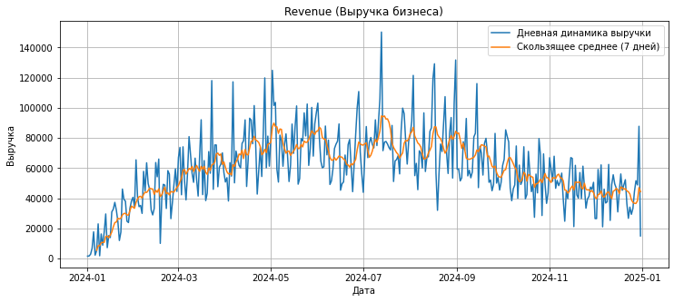

```python
# Добавим скользящее среднее за 7 дней
revenue_daily['rolling_7d'] = (
    revenue_daily
    .sort_values('order_date')
    .rolling(7)
    .mean()
    .reset_index(level=0, drop=True)
)

# Построим график
plt.figure(figsize=(12, 5))
plt.plot(revenue_daily['order_date'], revenue_daily['revenue'], label='Дневная динамика выручки')
plt.plot(revenue_daily['order_date'], revenue_daily['rolling_7d'], label='Скользящее среднее (7 дней)')
plt.title('Revenue (Выручка бизнеса)')
plt.xlabel('Дата')
plt.ylabel('Выручка')
plt.legend()
plt.grid()
plt.show()
```

В 2024 году выручка бизнеса быстро росла в первом полугодии, затем стабилизировалась и во второй половине года показала умеренное снижение. При высокой дневной волатильности сглаженная динамика не содержит резких провалов, что указывает на в целом стабильное состояние продукта.

- Чтобы разобраться, стали ли пользователи приносить меньше денег или их просто стало меньше, проанализируем **ARPU** и **ARPPU** в разрезе месяцев.

```python
# ARPU - средняя выручка на всех пользователей
orders_df['month'] = pd.to_datetime(orders_df['order_date']).dt.to_period('M').dt.start_time

arpu_arppu = (orders_df
        .groupby('month', as_index=False)
        .agg(revenue=('revenue', 'sum'),
            paying_users=('user_id', 'nunique'))
       )

# Добавим всех активных пользователей на этот месяц
arpu_arppu['total_users'] = (arpu_arppu['month']
                       .apply(lambda x: pa_marketplace_users[pa_marketplace_users['cohort_month'] <= x]['user_id'].nunique())
                      )

# Считаем ARPU и ARPPU
arpu_arppu['arpu'] = arpu_arppu['revenue'] / arpu_arppu['total_users']
arpu_arppu['arppu'] = arpu_arppu['revenue'] / arpu_arppu['paying_users']

display(arpu_arppu)
```

|  | month | revenue | paying_users | total_users | arpu | arppu |
| --- | --- | --- | --- | --- | --- | --- |
| 0 | 2024-01-01 | 6.426611e+05 | 454 | 2985 | 215.296855 | 1415.553109 |
| 1 | 2024-02-01 | 1.291004e+06 | 839 | 5696 | 226.650953 | 1538.741151 |
| 2 | 2024-03-01 | 1.911340e+06 | 1165 | 8661 | 220.683545 | 1640.635353 |
| 3 | 2024-04-01 | 2.120328e+06 | 1324 | 11566 | 183.324201 | 1601.455971 |
| 4 | 2024-05-01 | 2.457460e+06 | 1404 | 14632 | 167.951071 | 1750.327689 |
| 5 | 2024-06-01 | 2.093764e+06 | 1230 | 17442 | 120.041519 | 1702.247294 |
| 6 | 2024-07-01 | 2.427411e+06 | 1385 | 21830 | 111.196086 | 1752.642996 |
| 7 | 2024-08-01 | 2.448760e+06 | 1385 | 26261 | 93.247014 | 1768.057642 |
| 8 | 2024-09-01 | 1.922230e+06 | 1163 | 30727 | 62.558332 | 1652.820175 |
| 9 | 2024-10-01 | 1.708540e+06 | 999 | 35167 | 48.583612 | 1710.250120 |
| 10 | 2024-11-01 | 1.464642e+06 | 847 | 39550 | 37.032665 | 1729.211214 |
| 11 | 2024-12-01 | 1.332659e+06 | 803 | 44151 | 30.184127 | 1659.600727 |

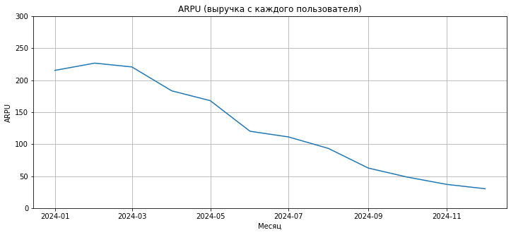

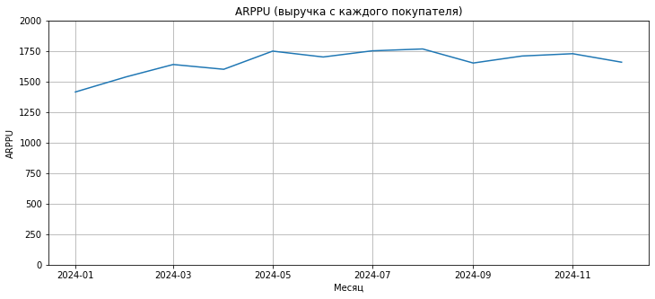

```python
# График ARPU
plt.figure(figsize=(12,5))
plt.plot(arpu_arppu['month'], arpu_arppu['arpu'])
plt.title('ARPU (выручка с каждого пользователя)')
plt.xlabel('Месяц')
plt.ylabel('ARPU')
plt.ylim(0, 300)
plt.grid()

# График ARPPU
plt.figure(figsize=(12,5))
plt.plot(arpu_arppu['month'], arpu_arppu['arppu'])
plt.title('ARPPU (выручка с каждого покупателя)')
plt.xlabel('Месяц')
plt.ylabel('ARPPU')
plt.ylim(0, 2000)
plt.grid()
plt.show()
```

ARPU на протяжении года резко снижается, а значит база пользователей растёт быстрее, чем их вклад в выручку. При этом ARPPU остаётся высоким и стабильным: платящие пользователи готовы тратить и видят ценность продукта. Маркетплейс умеет зарабатывать на платящих пользователях, но плохо превращает новых пользователей в покупателей. Основная точка роста - это улучшение онбординга и активации аудитории.

- Рассмотрим **AOV** - средний чек одного заказа. Это позволит понять внутреннюю механику продаж: стабильность ARPPU держится на дорогих товарах или на том, что пользователи стали чаще совершать мелкие покупки?

```python
# Рассчитаем AOV
aov = (
    orders_df
    .groupby('order_month', as_index=False)
    .agg(total_sales=('total_price', 'sum'),
         orders_count=('order_id', 'nunique'))
)

aov['aov'] = aov['total_sales'] / aov['orders_count']

display(aov)
```

|  | order_month | total_sales | orders_count | aov |
| --- | --- | --- | --- | --- |
| 0 | 2024-01-01 | 12853222.23 | 957 | 13430.744232 |
| 1 | 2024-02-01 | 25820076.52 | 1902 | 13575.224248 |
| 2 | 2024-03-01 | 38226803.72 | 2758 | 13860.334924 |
| 3 | 2024-04-01 | 42406554.11 | 3098 | 13688.364787 |
| 4 | 2024-05-01 | 49149201.52 | 3489 | 14086.902127 |
| 5 | 2024-06-01 | 41875283.43 | 3033 | 13806.555697 |
| 6 | 2024-07-01 | 48548210.99 | 3385 | 14342.159820 |
| 7 | 2024-08-01 | 48975196.68 | 3365 | 14554.293218 |
| 8 | 2024-09-01 | 38444597.28 | 2737 | 14046.254030 |
| 9 | 2024-10-01 | 34170797.40 | 2459 | 13896.216917 |
| 10 | 2024-11-01 | 29292837.96 | 1972 | 14854.380304 |
| 11 | 2024-12-01 | 26653187.67 | 1932 | 13795.645792 |

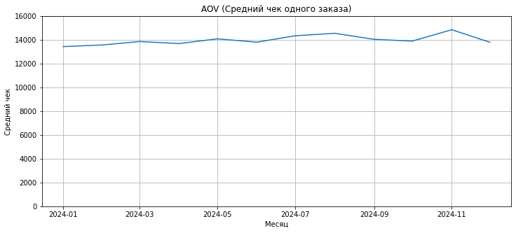

```python
# Построим график
plt.figure(figsize=(12, 5))
plt.plot(aov['order_month'], aov['aov'])
plt.title('AOV (Средний чек одного заказа)')
plt.xlabel('Месяц')
plt.ylabel('Средний чек')
plt.ylim(0, 16000)
plt.grid()
plt.show()
```

Средний чек (AOV) на протяжении года демонстрирует стабильность, колеблясь в узком диапазоне около 14 000. Значит качество покупок не падает. Пользователи продолжают покупать товары той же ценовой категории. Проблема снижения выручки во втором полугодии связана не с тем, что старые клиенты стали экономить, а с тем, что их просто становится недостаточно для перекрытия растущей базы неактивных пользователей.

- Рассчитаем общую конверсию в заказ - **CR** по месяцам, чтобы увидеть реальную долю активных покупателей. Мы сопоставим количество реальных покупателей с общим числом активных пользователей (MAU), которых подробнее рассмотрим в следующем разделе.

```python
# Подготовим датасет
events_df = pa_marketplace_events.copy()
events_df['event_date'] = events_df['event_date'].dt.date
events_df['week'] = pd.to_datetime(events_df['event_date']).dt.to_period('W').dt.start_time
events_df['month'] = pd.to_datetime(events_df['event_date']).dt.to_period('M').dt.start_time

# Рассчитаем MAU
mau = events_df.groupby('month')['user_id'].nunique().reset_index(name='mau')

# Объединим данные о платящих пользователях и активных пользователях
cr = arpu_arppu[['month', 'paying_users']].copy()
cr = cr.merge(mau, on='month')

# Рассчитаем CR в заказ
cr['cr'] = round((cr['paying_users'] / cr['mau']) * 100, 2)

display(cr)
```

|  | month | paying_users | mau | cr |
| --- | --- | --- | --- | --- |
| 0 | 2024-01-01 | 454 | 1149 | 39.51 |
| 1 | 2024-02-01 | 839 | 2162 | 38.81 |
| 2 | 2024-03-01 | 1165 | 2844 | 40.96 |
| 3 | 2024-04-01 | 1324 | 3059 | 43.28 |
| 4 | 2024-05-01 | 1404 | 3310 | 42.42 |
| 5 | 2024-06-01 | 1230 | 3174 | 38.75 |
| 6 | 2024-07-01 | 1385 | 3481 | 39.79 |
| 7 | 2024-08-01 | 1385 | 3861 | 35.87 |
| 8 | 2024-09-01 | 1163 | 3744 | 31.06 |
| 9 | 2024-10-01 | 999 | 3581 | 27.90 |
| 10 | 2024-11-01 | 847 | 3462 | 24.47 |
| 11 | 2024-12-01 | 803 | 3336 | 24.07 |

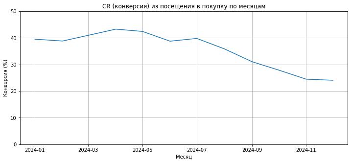

```python
# Построим график
plt.figure(figsize=(12, 5))
plt.plot(cr['month'], cr['cr'])
plt.title('CR (конверсия) из посещения в покупку по месяцам')
plt.xlabel('Месяц')
plt.ylabel('Конверсия (%)')
plt.ylim(0, 50)
plt.grid()
plt.show()
```

Начиная с апреля, наблюдается устойчивый нисходящий тренд конверсии в покупку. Если весной конверсия достигала своего пика в 43.28%, то к декабрю она упала почти вдвое — до 24.07%.

Это говорит о том, что с каждым месяцем всё большая доля активных пользователей (MAU) не доходит до покупки. Привлекаемая аудитория либо менее целевая, либо сталкивается с барьерами, которые мешают совершить первый заказ.

**Вывод:**

- Метрики ARPPU и AOV остаются стабильно высокими. Это значит, что те пользователи, которые совершают покупки, лояльны к продукту, покупают на привычные суммы и приносят стабильный доход.
- Основной негативный тренд - резкое падение ARPU (с 226 до 30) и CR (с 43% до 24%). Это признак того, что рост базы пользователей происходит экстенсивно. Т.е. продукт не умеет удерживать интерес активных пользователей и конвертировать их в покупателей.
- Из-за падения конверсии рост аудитории перестал трансформироваться в рост выручки, что привело к её стабилизации и последующему плавному снижению во втором полугодии.

Текущая динамика указывает на наличие значительного потенциала в области активации и онбординга новых пользователей. Дальнейшее наращивание трафика без исправления воронки будет приводить к неэффективным тратам бюджета.

### 2.2 Активность и лояльность аудитории

- Рассмотрим **DAU/WAU/MAU, Stickiness** для изучения динамики активности пользователей и их вовлечённости в продукт.

```python
# Рассчитаем DAU/WAU
dau = events_df.groupby('event_date')['user_id'].nunique().reset_index(name='dau')
wau = events_df.groupby('week')['user_id'].nunique().reset_index(name='wau')
```

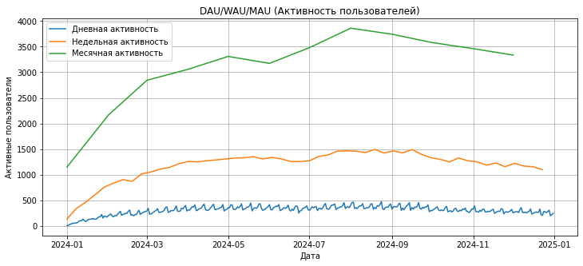

```python
# Построим графики
plt.figure(figsize=(12, 5))
plt.plot(dau['event_date'], dau['dau'], label='Дневная активность')
plt.plot(wau['week'][:-1], wau['wau'][:-1], label='Недельная активность')
plt.plot(mau['month'], mau['mau'], label='Месячная активность')
plt.title('DAU/WAU/MAU (Активность пользователей)')
plt.xlabel('Дата')
plt.ylabel('Активные пользователи')
plt.legend()
plt.grid()
plt.show()
```

В начале года наблюдается активный рост всех метрик: DAU, WAU и MAU, что отражает успешное привлечение новых пользователей.

- Дневная активность (DAU) демонстрирует заметные колебания, характерные для маркетплейса с различной нагрузкой по дням недели.
- Недельная (WAU) и месячная активность (MAU) имеют более сглаженный тренд: рост в первые месяцы года, пик в августе и умеренный спад во второй половине года. Для визуализации последняя неполная неделя WAU была исключена, что делает тренд более корректным.

Произведем расчёт метрики **Stickiness**.

```python
# Рассчитаем среднемесячные dau
dau['month'] = pd.to_datetime(dau['event_date']).dt.to_period('M').dt.start_time
dau_monthly = (dau
               .groupby('month', as_index=False)
               .agg(avg_dau=('dau', 'mean'))
               )

# Расчёт Stickness
stick = pd.merge(mau, dau_monthly, how='left', on='month')
stick['stick'] = round((stick['avg_dau'] / stick['mau']) * 100, 2)

display(stick)
```

|  | month | mau | avg_dau | stick |
| --- | --- | --- | --- | --- |
| 0 | 2024-01-01 | 1149 | 110.129032 | 9.58 |
| 1 | 2024-02-01 | 2162 | 235.310345 | 10.88 |
| 2 | 2024-03-01 | 2844 | 302.935484 | 10.65 |
| 3 | 2024-04-01 | 3059 | 344.733333 | 11.27 |
| 4 | 2024-05-01 | 3310 | 359.161290 | 10.85 |
| 5 | 2024-06-01 | 3174 | 343.766667 | 10.83 |
| 6 | 2024-07-01 | 3481 | 362.903226 | 10.43 |
| 7 | 2024-08-01 | 3861 | 380.838710 | 9.86 |
| 8 | 2024-09-01 | 3744 | 363.566667 | 9.71 |
| 9 | 2024-10-01 | 3581 | 311.000000 | 8.68 |
| 10 | 2024-11-01 | 3462 | 292.200000 | 8.44 |
| 11 | 2024-12-01 | 3336 | 266.967742 | 8.00 |

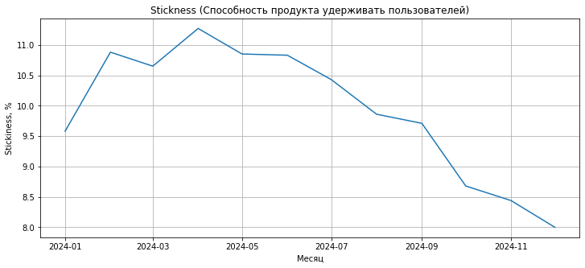

```python
# Построим графики
plt.figure(figsize=(12, 5))
plt.plot(stick['month'], stick['stick'])
plt.title('Stickness (Cпособность продукта удерживать пользователей)')
plt.xlabel('Месяц')
plt.ylabel('Stickiness, %')
plt.grid()
plt.show()
```

Показатель Stickiness демонстрирует умеренную, но устойчивую тенденцию к снижению во втором полугодии. Это означает, что пользователи стали реже заходить в приложение.

Снижение вовлеченности во втором полугодии по времени совпадает с падением конверсии в заказ и ARPU. Это подтверждает, что новые пользователи не только меньше покупают, но и в целом меньше интересуются продуктом после первого знакомства.

Нисходящий тренд Stickiness указывает на то, что приток новой аудитории во второй половине года менее лоялен или менее заинтересован в функционале платформы.

**Вывод:**

Динамика метрик показывает, что после периода бурного роста в начале года, маркетплейс перешел в стадию стагнации. Несмотря на то, что MAU удерживается на высоком уровне, качественные показатели активности (Stickiness) падают вслед за показателями монетизации. Это еще раз подчеркивает необходимость работы над активацией, чтобы превратить заходящую аудиторию в вовлеченных пользователей.

### 2.3 Юнит-экономика и маркетинг

- Проанализируем метрики **CAC, ROI, LTV** и **Payback Period**, чтобы оценить эффективность маркетинга: стоимость привлечения клиента, его способность окупить маркетинговые затраты за счёт комиссии (5%) и общую отдачу от вложений в продвижение.

```python
# Рассчитаем маркетинговые затраты по месяцам
marketing_monthly = (
    pa_marketplace_campaign_costs
    .groupby('spend_month', as_index=False)
    .agg(total_budget=('budget', 'sum'))
)

# Объединяем с данными о монетизации
unit_economic = arpu_arppu.merge(marketing_monthly, left_on='month', right_on='spend_month', how='left')

# Расчет CAC
unit_economic['cac'] = unit_economic['total_budget'] / unit_economic['paying_users']

# Расчет ROI
unit_economic['roi'] = (unit_economic['revenue'] - unit_economic['total_budget']) / unit_economic['total_budget'] * 100

# Расчет LTV упрощенный
unit_economic['ltv'] = unit_economic['revenue'] / unit_economic['paying_users']

display(unit_economic[['month', 'total_budget', 'cac', 'ltv', 'roi']].round(2))
```

|  | month | total_budget | cac | ltv | roi |
| --- | --- | --- | --- | --- | --- |
| 0 | 2024-01-01 | 1177456.97 | 2593.52 | 1415.55 | -45.42 |
| 1 | 2024-02-01 | 1061385.93 | 1265.06 | 1538.74 | 21.63 |
| 2 | 2024-03-01 | 1167680.37 | 1002.30 | 1640.64 | 63.69 |
| 3 | 2024-04-01 | 1147739.92 | 866.87 | 1601.46 | 84.74 |
| 4 | 2024-05-01 | 1225322.28 | 872.74 | 1750.33 | 100.56 |
| 5 | 2024-06-01 | 1130439.77 | 919.06 | 1702.25 | 85.22 |
| 6 | 2024-07-01 | 1776446.60 | 1282.63 | 1752.64 | 36.64 |
| 7 | 2024-08-01 | 1811677.75 | 1308.07 | 1768.06 | 35.17 |
| 8 | 2024-09-01 | 1820718.83 | 1565.54 | 1652.82 | 5.58 |
| 9 | 2024-10-01 | 1810802.57 | 1812.62 | 1710.25 | -5.65 |
| 10 | 2024-11-01 | 1773970.36 | 2094.42 | 1729.21 | -17.44 |
| 11 | 2024-12-01 | 1858569.86 | 2314.53 | 1659.60 | -28.30 |

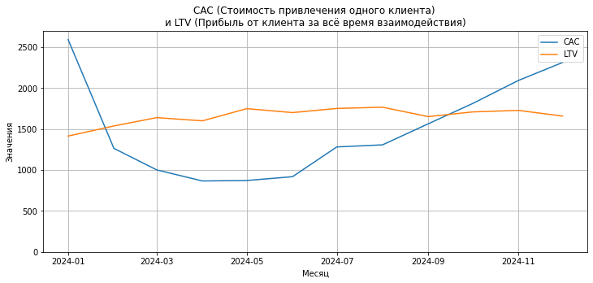

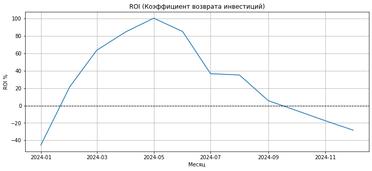

```python
# Графикb CAC и LTV
plt.figure(figsize=(12,5))
plt.plot(unit_economic['month'], unit_economic['cac'], label='CAC')
plt.plot(unit_economic['month'], unit_economic['ltv'], label='LTV')
plt.title('CAC (Стоимость привлечения одного клиента) \nи LTV (Прибыль от клиента за всё время взаимодействия)')
plt.xlabel('Месяц')
plt.ylabel('Значения')
plt.ylim(0, 2700)
plt.legend()
plt.grid()


# График ROI
plt.figure(figsize=(12,5))
plt.plot(unit_economic['month'], unit_economic['roi'])
plt.axhline(0, color='black', linewidth=1, linestyle='--')
plt.title('ROI (Коэффициент возврата инвестиций)')
plt.xlabel('Месяц')
plt.ylabel('ROI %')
plt.grid()
plt.show()
```

```python
# Добавим расчет AOV в таблицу unit_economic
unit_economic = unit_economic.merge(aov[['order_month', 'aov']], left_on='month', right_on='order_month', how='left')

# Рассчитаем, какую прибыль приносит один средний заказ (5% от чека)
unit_economic['profit_per_order'] = unit_economic['aov'] * 0.05

# Рассчитаем Payback Period
unit_economic['payback_orders'] = unit_economic['cac'] / unit_economic['profit_per_order']

display(unit_economic[['month', 'cac', 'profit_per_order', 'payback_orders']].round(2))
```

|  | month | cac | profit_per_order | payback_orders |
| --- | --- | --- | --- | --- |
| 0 | 2024-01-01 | 2593.52 | 671.54 | 3.86 |
| 1 | 2024-02-01 | 1265.06 | 678.76 | 1.86 |
| 2 | 2024-03-01 | 1002.30 | 693.02 | 1.45 |
| 3 | 2024-04-01 | 866.87 | 684.42 | 1.27 |
| 4 | 2024-05-01 | 872.74 | 704.35 | 1.24 |
| 5 | 2024-06-01 | 919.06 | 690.33 | 1.33 |
| 6 | 2024-07-01 | 1282.63 | 717.11 | 1.79 |
| 7 | 2024-08-01 | 1308.07 | 727.71 | 1.80 |
| 8 | 2024-09-01 | 1565.54 | 702.31 | 2.23 |
| 9 | 2024-10-01 | 1812.62 | 694.81 | 2.61 |
| 10 | 2024-11-01 | 2094.42 | 742.72 | 2.82 |
| 11 | 2024-12-01 | 2314.53 | 689.78 | 3.36 |

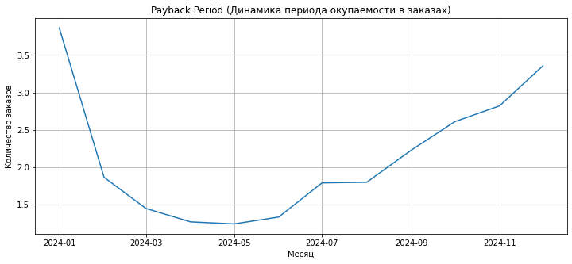

```python
# График Payback Period
plt.figure(figsize=(12,5))
plt.plot(unit_economic['month'], unit_economic['payback_orders'])
plt.title('Payback Period (Динамика периода окупаемости в заказах)')
plt.xlabel('Месяц')
plt.ylabel('Количество заказов')
plt.grid()
plt.show()
```

- Весной бизнес находился в зоне высокой эффективности: для окупаемости привлечения пользователя было достаточно ~1.25 заказа.
- К концу года ситуация резко ухудшилась: для выхода в ноль уже требуется более 3.3 заказа на одного нового клиента.
- Привлечение новых пользователей в текущей модели перестало окупаться и несёт высокий риск невозврата инвестиций.

**Итоговое резюме по ключевым метрикам:**

Анализ показал, что у маркетплейса есть лояльные покупатели, которые обеспечивают стабильно высокий средний чек (~14 000) и предсказуемый доход с клиента (LTV). Однако общая эффективность бизнеса падает из-за проблем на входе в воронку.

**Рекомендация:**

Улучшить онбординг и вовлечение аудитории, персонализацию. Необходимо превратить пассивных пользователей в активных покупателей, чтобы вернуть стоимость привлечения в рамки окупаемости.

### 3 Текущее состояние продукта и ключевые риски

**Общая динамика продукта**

- В первой половине года маркетплейс демонстрирует активный рост аудитории и выручки. DAU, WAU и MAU растут синхронно, что говорит об эффективном привлечении пользователей и первичной активации. Пик активности и выручки приходится на летние месяцы.
- Во второй половине года (с августа) рост замедляется: MAU стабилизируется, а затем начинает снижаться, что указывает на насыщение аудитории и снижение вовлечённости новых пользователей.

**Монетизация и поведение платящих пользователей**

- ARPPU и AOV остаются стабильно высокими на протяжении всего года. Это означает, что пользователи, которые доходят до покупки, готовы тратить сопоставимые суммы. Ядро платящих пользователей сформировано.
- При этом ARPU демонстрирует резкое падение (с 226 в начале года до 30 к декабрю). Основная причина - быстрый рост общей пользовательской базы при одновременном снижении доли платящих пользователей.

**Конверсия и эффективность воронки**

- Конверсия из активного пользователя (MAU) в покупателя (CR) достигает максимума весной (43%), после чего устойчиво снижается и к декабрю падает до 24%.
- Это означает, что всё большая часть активной аудитории не доходит до заказа. Рост MAU перестаёт конвертироваться в рост выручки, что приводит к её стагнации и постепенному снижению во втором полугодии.

**Юнит-экономика и окупаемость привлечения**

- Весной привлечение нового пользователя было экономически эффективным: для окупаемости CAC требовалось около 1.25 заказа. К концу года порог окупаемости вырос более чем в 2.5 раза — до 3.3 заказа на пользователя. С учётом реальной частоты покупок на маркетплейсах это делает текущее масштабирование трафика экономически нецелесообразным.

**Итоговый вывод**

- Продукт хорошо зарабатывает на тех пользователях, которые доходят до покупки, но всё хуже превращает новых пользователей в покупателей. Аудитория растёт, но её качество постепенно снижается.
- Ключевая точка роста находится не в увеличении маркетинговых бюджетов, а в улучшении воронки: онбординга, первого заказа и возврата пользователей. Без решения этих проблем дальнейшее масштабирование будет приводить к росту затрат без пропорционального роста выручки.

## 4 Поиск инсайтов, точек роста и сегментация

После того как мы провели верхнеуровневую оценку данных, самое время переходить от общей картины к точечным наблюдениям. Посмотрим вглубь данных: по каналам, сегментам пользователей, категориям товаров, регионам, типам устройств. Найдем закономерности, различия, аномалии.

**Цель** — сформировать обоснованные гипотезы:

- какие сегменты работают лучше остальных
- какие сегменты работают хуже остальных
- на каких этапах воронки теряются пользователи
- какие группы можно или нужно масштабировать
- куда стоит инвестировать больше внимания или ресурсов

По итогам анализа также:

- сформулируем выводы в виде аналитической записки
- сформулируем несколько гипотез, которые помогут развить продукт.

### 4.1 Анализ по каналам привлечения

Рассмотри каналы привлечения, чтобы понять, какие каналы приводят качественную аудиторию, а какие создают объём без выручки и ухудшают ключевые метрики (ARPU, CR).

Для поиска точек роста мы проанализируем эффективность каналов через следующие метрики:

- Конверсия в покупку (CR): чтобы понять, насколько целевой трафик приходит из каждого источника.
- Экономика канала (CAC, ROI): сравним стоимость привлечения платящего пользователя с его окупаемостью.
- Качество монетизации (ARPPU): Проверим, отличаются ли по покупательской способности клиенты из разных источников.

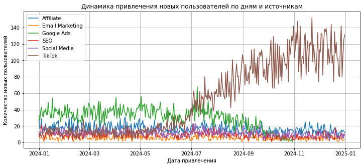

```python
# Приведем день регистрации к дате
pa_marketplace_users['registration_date'] = pd.to_datetime(pa_marketplace_users['registration_date']).dt.date

# Рассчитаем динамику набора новых пользователей по дням в каждом источнике
daily_new_users = (pa_marketplace_users
                   .groupby(['registration_date', 'acq_channel'])['user_id']
                   .nunique()
                   .reset_index(name='new_users'))

# Cтроим график
plt.subplots(figsize=(12,5))

sns.lineplot(data=daily_new_users,
             x='registration_date',
             y='new_users',
             hue='acq_channel')

plt.title('Динамика привлечения новых пользователей по дням и источникам')
plt.xlabel('Дата привлечения')
plt.ylabel('Количество новых пользователей')
plt.legend()
plt.grid()
plt.show()
```

- Начиная с лета 2024 года `TikTok` стал крупнейшим источником привлечения пользователей, значительно опережая остальные. Судя по всему, новая маркетинговая стратегия сделала ставку именно на этот канал, чтобы обеспечить маркетплейсу максимальный приток аудитории.
- Однако на фоне этого роста мы видим синхронное падение общей конверсии. Это наводит на мысль, что огромный поток пользователей из `TikTok` пока не готов покупать так же активно, как аудитория из более традиционных источников.

```python
# Присоединим информацию о каналах привлечениях пользователей к таблице событий
events_channels_df = events_df.merge(pa_marketplace_users[['user_id', 'acq_channel']], on='user_id')

# Рассчитаем MAU по каналам
metrics_monthly = (events_channels_df
           .groupby(['acq_channel', 'month'])['user_id']
           .nunique()
           .reset_index(name='mau'))

# Рассчитаем Paying Users и Revenue
orders_channels_df = orders_df.merge(pa_marketplace_users[['user_id', 'acq_channel']], on='user_id')

paying_users = (orders_channels_df
               .groupby(['acq_channel', 'month'], as_index=False)
               .agg(paying_users = ('user_id', 'nunique'),
                    total_sales = ('total_price', 'sum')))
paying_users['revenue'] = paying_users['total_sales'] * 0.05

# Объединяем с metrics
metrics_monthly = metrics_monthly.merge(paying_users[['acq_channel', 'month', 'paying_users', 'revenue']], on=['acq_channel', 'month'], how='left')

# Считаем CR
metrics_monthly['cr'] = round(metrics_monthly['paying_users'] / metrics_monthly['mau'] * 100, 2)

# Объединяем с затраттами на маркетинг
metrics_monthly = (metrics_monthly
                   .merge(pa_marketplace_campaign_costs,
                          left_on=['acq_channel', 'month'],
                          right_on=['acq_channel', 'spend_month'], how='left')
                   .drop(columns=['spend_month']))

# Считаем CAC и ROI
metrics_monthly['cac'] = metrics_monthly['budget'] / metrics_monthly['paying_users']
metrics_monthly['roi'] = (metrics_monthly['revenue'] - metrics_monthly['budget']) / metrics_monthly['budget'] * 100
metrics_monthly['arppu'] = metrics_monthly['revenue'] / metrics_monthly['paying_users']

display(metrics_monthly.round(2).head())
```

|  | acq_channel | month | mau | paying_users | revenue | cr | budget | cac | roi | arppu |
| --- | --- | --- | --- | --- | --- | --- | --- | --- | --- | --- |
| 0 | Affiliate | 2024-01-01 | 240 | 113 | 147274.58 | 47.08 | 179343.39 | 1587.11 | -17.88 | 1303.31 |
| 1 | Affiliate | 2024-02-01 | 464 | 237 | 378194.89 | 51.08 | 175488.49 | 740.46 | 115.51 | 1595.76 |
| 2 | Affiliate | 2024-03-01 | 568 | 313 | 589098.97 | 55.11 | 164543.48 | 525.70 | 258.02 | 1882.11 |
| 3 | Affiliate | 2024-04-01 | 657 | 366 | 591134.26 | 55.71 | 186869.98 | 510.57 | 216.33 | 1615.12 |
| 4 | Affiliate | 2024-05-01 | 717 | 388 | 776033.16 | 54.11 | 166443.78 | 428.98 | 366.24 | 2000.09 |

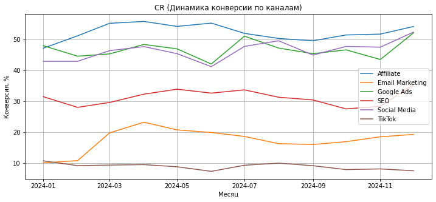

```python
# Построим график CR
plt.figure(figsize=(12, 5))
sns.lineplot(data=metrics_monthly, x='month', y='cr', hue='acq_channel')
plt.title('CR (Динамика конверсии по каналам)')
plt.ylabel('Конверсия, %')
plt.xlabel('Месяц')
plt.grid()
plt.legend()
plt.show()
```

- `TikTok` привлекает много пользователей, но почти не конвертирует их в покупателей (8–10%).
- Эффективные каналы: `Affiliate`, `Google Ads`, `Social Media` c конверсией 45–55%, `SEO` стабильно около 30%.
- Стоит перераспределять бюджет с `TikTok` на каналы с высокой конверсией.

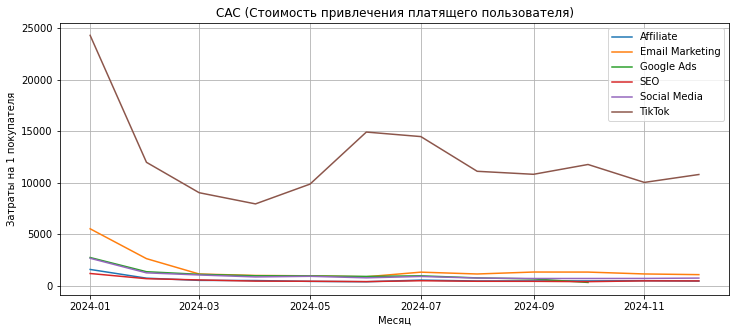

```python
# Построим график CAC
plt.figure(figsize=(12, 5))
sns.lineplot(data=metrics_monthly, x='month', y='cac', hue='acq_channel')
plt.title('CAC (Стоимость привлечения платящего пользователя)')
plt.ylabel('Затраты на 1 покупателя')
plt.xlabel('Месяц')
plt.grid()
plt.legend()
plt.show()
```

- `TikTok` стал основным драйвером роста базы пользователей, однако этот трафик оказался самым низкоэффективным. Несмотря на массовый приток аудитории из этого канала с июля 2024 года, его конверсия стабильно остается самой низкой (ниже 10%), а стоимость привлечения платящего пользователя (CAC) - аномально высокой по сравнению с другими источниками.
- В то же время такие каналы, как `Affiliate` и `Google Ads`, демонстрируют кратно более высокую конверсию (около 50%) при минимальных затратах на одного покупателя, что делает их ключевыми точками для эффективного масштабирования.

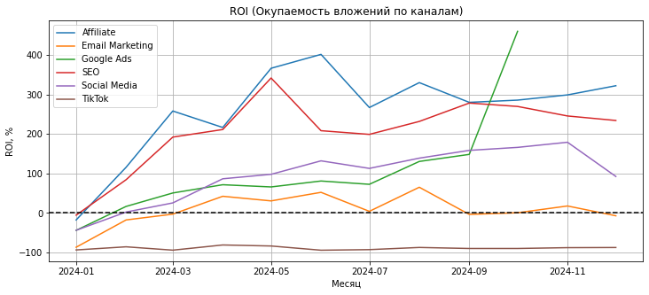

```python
# Построим график ROI
plt.figure(figsize=(12, 5))
sns.lineplot(data=metrics_monthly, x='month', y='roi', hue='acq_channel')
plt.axhline(0, color='black', linestyle='--')
plt.title('ROI (Окупаемость вложений по каналам)')
plt.ylabel('ROI, %')
plt.xlabel('Месяц')
plt.grid()
plt.legend()
plt.show()
```

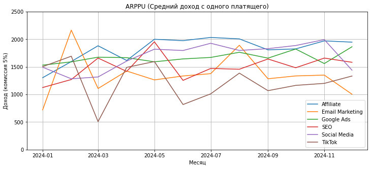

```python
# Построим график ARPPU
plt.figure(figsize=(12, 5))
sns.lineplot(data=metrics_monthly, x='month', y='arppu', hue='acq_channel')
plt.title('ARPPU (Средний доход с одного платящего)')
plt.ylabel('Доход (комиссия 5%)')
plt.xlabel('Месяц')
plt.ylim(0, 2500)
plt.grid()
plt.legend()
plt.show()
```

- ARPPU показывает, что средний доход с одного платящего пользователя остается относительно стабильным для большинства каналов, колеблясь в диапазоне 1300–2000.
- `TikTok` демонстрирует наиболее волатильную динамику с просадками до 500, однако к концу года доходность его платящей аудитории выровнялась с остальными источниками. Это подтверждает гипотезу о том, что проблема бизнеса кроется не в низком качестве самих покупателей, а в аномально высокой стоимости их привлечения через социальные сети.

**Вывод по анализу каналов привлечения:**

Проведенный анализ выявил критический дисбаланс в текущей маркетинговой стратегии. Основной объем трафика во втором полугодии обеспечивается за счет канала с наихудшими показателями эффективности `TikTok`.

- `TikTok`: несмотря на то, что канал стал лидером по притоку новых пользователей с лета 2024 года, он демонстрирует аномально низкую конверсию (8–10%) и крайне высокую стоимость привлечения платящего пользователя (CAC). Это привело к тому, что ROI канала стабильно находится в отрицательной зоне около -90%.
- Каналы `Affiliate`, `Google Ads` и `Social Media` показывают кратно более высокую конверсию (45–55%). При этом `Affiliate` и `SEO` являются фундаментом прибыльности, демонстрируя стабильно положительный ROI на протяжении большей части года.
- Показатель ARPPU подтверждает, что пользователи из всех каналов, включая `TikTok`, обладают схожей покупательской способностью (в среднем 1300–2000 дохода с клиента). Это доказывает, что проблема не в качестве самих покупателей, а в неэффективной воронке активации и чрезмерных затратах на привлечение в нерентабельных каналах.
- `Google Ads`: к концу года канал показал резкий скачок ROI на фоне снижения объемов привлечения, что указывает на высокую эффективность работы с узкой, целевой аудиторией.

**Рекомендация:**

Необходимо радикально пересмотреть бюджет в пользу `Affiliate` и `SEO`. Дальнейшее масштабирование через `TikTok` при текущем уровне конверсии экономически нецелесообразно и ведет к накоплению убытков.

### 4.2 Сегментация по типу пользователей

Чтобы понять, что именно тянет метрики вниз, мы проведем двухуровневый анализ. Сначала проверим, кто больше приносит прибыли (новые пользователи или веозвращающиеся), а затем оценим покупателей через частоту их покупок.

### 4.2.1 Анализ новых пользователей и возвращающихся

Чтобы глубже понять причины падения эффективности, необходимо разделить общие метрики на две группы: поведение тех, кто зарегистрировался в текущем месяце и тех, кто пришел раньше.

Проверим гипотезу о том, что лояльные пользователи продолжают приносить стабильный доход, в то время как новые пользователи не доходят до первого заказа.

В этом разделе мы проанализируем:

- CR новых и возвращающихся пользователей
- ARPPU в разрезе сегментов
- Долю выручки, которую генерирует каждый сегмент.

```python
# Добавим флаг по типу пользователя для каждого месяца
events_users_type = events_df.merge(pa_marketplace_users[['user_id', 'cohort_month']], on='user_id', how='inner')
orders_users_type = orders_df.merge(pa_marketplace_users[['user_id', 'cohort_month']], on='user_id', how='inner')

# Флаг пользователя: 1-новый пользователь, 0-возвращающийся
events_users_type['new_user'] = (events_users_type['event_month'] == events_users_type['cohort_month']).astype(int)
orders_users_type['new_user'] = (orders_users_type['order_month'] == orders_users_type['cohort_month']).astype(int)

# Рассчитаем MAU по типам пользователей
metrics_users_type = (events_users_type
           .groupby(['new_user', 'month'])['user_id']
           .nunique()
           .reset_index(name='mau'))

# Рассчитаем Paying Users и Revenue
paying_users_type = (orders_users_type
               .groupby(['new_user', 'month'], as_index=False)
               .agg(paying_users = ('user_id', 'nunique'),
                    total_sales = ('total_price', 'sum')))

paying_users_type['revenue'] = paying_users_type['total_sales'] * 0.05

# Объединяем с metrics
metrics_users_type = (metrics_users_type
                      .merge(paying_users_type[['new_user', 'month', 'paying_users', 'revenue']],
                             on=['new_user', 'month'], how='left'))

# Считаем CR
metrics_users_type['cr'] = round(metrics_users_type['paying_users'] / metrics_users_type['mau'] * 100, 2)

# Считаем ARPPU
metrics_users_type['arppu'] = metrics_users_type['revenue'] / metrics_users_type['paying_users']

# Доля выручки сегмента в месяце
total_rev_month = (metrics_users_type
                   .groupby('month', as_index=False)
                   .agg(total_rev_month = ('revenue', 'sum')))

# Присоединяем к metrics_users_type
metrics_users_type = metrics_users_type.merge(total_rev_month, on='month', how='left')

# Доля выручки сегмента
metrics_users_type['revenue_share'] = (
    metrics_users_type['revenue'] / metrics_users_type['total_rev_month']
) * 100

display(metrics_users_type.head().round(2))
```

|  | new_user | month | mau | paying_users | revenue | cr | arppu | total_rev_month | revenue_share |
| --- | --- | --- | --- | --- | --- | --- | --- | --- | --- |
| 0 | 0 | 2024-02-01 | 1102 | 426 | 691854.34 | 38.66 | 1624.07 | 1238256.10 | 55.87 |
| 1 | 0 | 2024-03-01 | 1627 | 676 | 1212066.75 | 41.55 | 1793.00 | 1856977.44 | 65.27 |
| 2 | 0 | 2024-04-01 | 1844 | 811 | 1356343.83 | 43.98 | 1672.43 | 2071560.15 | 65.47 |
| 3 | 0 | 2024-05-01 | 2078 | 898 | 1654970.37 | 43.21 | 1842.95 | 2394155.15 | 69.13 |
| 4 | 0 | 2024-06-01 | 2153 | 864 | 1568667.68 | 40.13 | 1815.59 | 2037114.60 | 77.00 |

- Поскольку наши данные ограничены 2024 годом, в январе мы видим только новых пользователей. Для более корректного анализа динамики формирования лояльного ядра и сравнения сегментов, на графиках ниже мы рассмотрим период, начиная с февраля.

```python
# Фильтруем данные, оставляя только февраль 2024 и позже
plot_data = metrics_users_type[metrics_users_type['month'] >= '2024-02-01']
```

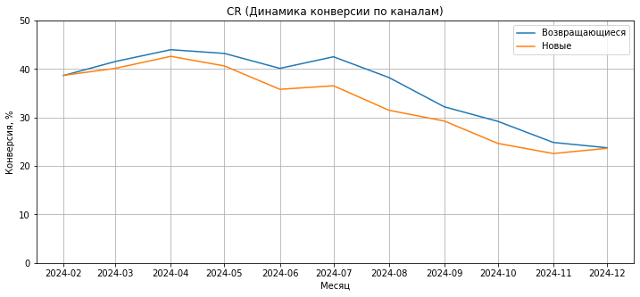

```python
# Построим график CR
plt.figure(figsize=(12, 5))
sns.lineplot(data=plot_data, x='month', y='cr', hue='new_user')
plt.title('CR (Динамика конверсии по каналам)')
plt.ylabel('Конверсия, %')
plt.xlabel('Месяц')
plt.ylim(0, 50)
plt.grid()
plt.legend(['Возвращающиеся', 'Новые'])
plt.show()
```

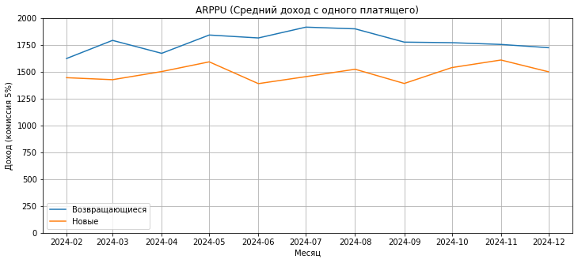

```python
# Построим график ARPPU
plt.figure(figsize=(12, 5))
sns.lineplot(data=plot_data, x='month', y='arppu', hue='new_user')
plt.title('ARPPU (Средний доход с одного платящего)')
plt.ylabel('Доход (комиссия 5%)')
plt.xlabel('Месяц')
plt.ylim(0, 2000)
plt.grid()
plt.legend(['Возвращающиеся', 'Новые'])
plt.show()
```

- Возвращающиеся пользователи стабильно приносят больше дохода за одну покупку: в среднем на 200–300 выше, чем новые.

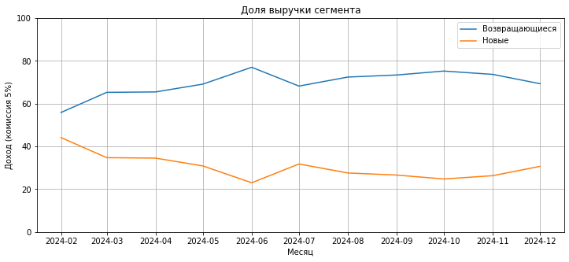

```python
# Построим график Доли выручки сегмента
plt.figure(figsize=(12, 5))
sns.lineplot(data=plot_data, x='month', y='revenue_share', hue='new_user')
plt.title('Доля выручки сегмента')
plt.ylabel('Доход (комиссия 5%)')
plt.xlabel('Месяц')
plt.ylim(0, 100)
plt.grid()
plt.legend(['Возвращающиеся', 'Новые'])
plt.show()
```

- График наглядно иллюстрирует, что, начиная с февраля, возвращающиеся пользователи стали основным финансовым активом, обеспечивая в среднем 70% всей выручки маркетплейса. Несмотря на массовый приток новой аудитории, вклад новичков в доход остается стабильно низким (около 30%), что что является нормальной и ожидаемой картиной для маркетплейса. Новые пользователи редко совершают покупку сразу.

**Вывод по анализу сегментации по типу новых и старых пользователей:**

Финансовая устойчивость маркетплейса держится на лояльных возвращающихся пользователях, в то время как эффективность работы с новой аудиторией снижается:

- Возвращающиеся пользователи генерируют основную часть дохода: от 55% до 77% всей выручки. Они не только приносят больше денег (ARPPU выше на 200–300), но и демонстрируют более высокую конверсию по сравнению с новичками.
- Массовый приток новых пользователей во втором полугодии (преимущественно из `TikTok`) не привел к росту их доли в выручке, которая стабилизировалась на отметке около 30%.
- Тревожным сигналом является снижение CR в обоих сегментах с июля, что указывает на перенасыщение платформы нецелевым трафиком, который хуже конвертируется в покупки.

### 4.2.2 Анализ пользователей по частоте покупок

- Изучим пользователей через частоту покупок. Это позволит понять, какую долю дохода приносят регулярные покупатели и не становится ли в нашей базе слишком много one-time клиентов, что может быть признаком некачественного трафика.

```python
# Объединяем заказы с данными о сегментах пользователей
orders_segment = orders_df.merge(pa_marketplace_users[['user_id', 'buyer_segment']], on='user_id', how='left')

# Рассчитываем ключевые метрики по сегментам и месяцам
metrics_segment = (orders_segment
                   .groupby(['buyer_segment', 'month'], as_index=False)
                   .agg(paying_users=('user_id', 'nunique'),
                        total_sales=('total_price', 'sum')))

metrics_segment['revenue'] = metrics_segment['total_sales'] * 0.05
metrics_segment['arppu'] = metrics_segment['revenue'] / metrics_segment['paying_users']

# Рассчитаем долю выручки сегмента в общем доходе месяца
monthly_total_rev = (metrics_segment
                   .groupby('month', as_index=False)
                   .agg(total_rev_month = ('revenue', 'sum')))

# Присоединяем к metrics_segment
metrics_segment = metrics_segment.merge(monthly_total_rev, on='month', how='left')

# Доля выручки сегмента
metrics_segment['revenue_share'] = (metrics_segment['revenue'] / metrics_segment['total_rev_month']) * 100

display(metrics_segment.head().round(2))
```

|  | buyer_segment | month | paying_users | total_sales | revenue | arppu | total_rev_month | revenue_share |
| --- | --- | --- | --- | --- | --- | --- | --- | --- |
| 0 | medium | 2024-01-01 | 170 | 3835360.44 | 191768.02 | 1128.05 | 617256.67 | 31.07 |
| 1 | medium | 2024-02-01 | 326 | 6856627.36 | 342831.37 | 1051.63 | 1238256.10 | 27.69 |
| 2 | medium | 2024-03-01 | 438 | 8361003.85 | 418050.19 | 954.45 | 1856977.44 | 22.51 |
| 3 | medium | 2024-04-01 | 506 | 10139714.76 | 506985.74 | 1001.95 | 2071560.15 | 24.47 |
| 4 | medium | 2024-05-01 | 516 | 11057637.07 | 552881.85 | 1071.48 | 2394155.15 | 23.09 |

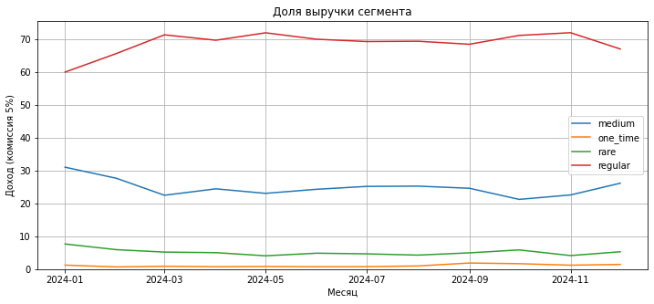

```python
# Построим график доли выручки
plt.figure(figsize=(12, 5))
sns.lineplot(data=metrics_segment, x='month', y='revenue_share', hue='buyer_segment')
plt.title('Доля выручки сегмента')
plt.ylabel('Доход (комиссия 5%)')
plt.xlabel('Месяц')
plt.ylim(0)
plt.grid()
plt.legend()
plt.show()
```

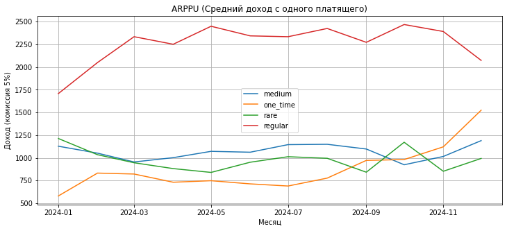

```python
# Построим ARPPU по сегментам
plt.figure(figsize=(12, 5))
sns.lineplot(data=metrics_segment, x='month', y='arppu', hue='buyer_segment')
plt.title('ARPPU (Средний доход с одного платящего)')
plt.ylabel('Доход (комиссия 5%)')
plt.xlabel('Месяц')
#plt.ylim(0)
plt.grid()
plt.legend()
plt.show()
```

**Вывод по анализу сегментации по частоте покупок:**

- Лояльные пользователи, покупающие регулярно, генерируют основную часть прибыли маркетплейса, обеспечивая стабильно около 70% всей выручки на протяжении всего года.
- Сегмент `regular` значительно превосходит остальные группы по среднему чеку, демонстрируя ARPPU в диапазоне 2000–2500. Это подтверждает, что удержание текущих активных клиентов приносит компании в 2–2.5 раза больше дохода с одной транзакции, чем работа с любым другим сегментом.
- Доля выручки от разовых и редких покупателей остается минимальной, а их ARPPU находится на самом низком уровне.
- На графике ARPPU виден резкий рост среднего чека сегмента `one_time` в декабре (до 1500), что может быть связано с сезонными праздничными покупками или акциями, однако их общая доля в выручке при этом не растет, оставаясь крайне низкой.

### 4.3 Сегментация по устройствам

Чтобы выявить возможные технические барьеры на пути пользователя к покупке проверим, насколько удобно совершать заказы с разных платформ. Наша задача - понять, как платформа влияет на желание и возможность совершить покупку.

Проанализируем:

- нет ли резкого падения конверсии на конкретной ОС, что указывало бы на ошибки в коде.
- с чего пользователи покупают эффективнее - с мобильных устройств, компьютеров или планшетов.
- как отличается ARPPU у пользователей разных платформ (например, iOS и macOS против Android и Windows).

```python
# Определяем основной девайс и ОС для каждого пользователя
users_device = (events_df
                 .groupby(['user_id', 'device', 'os'], as_index=False)
                 .agg(event_count = ('event_id', 'count'))
                 .sort_values(['user_id', 'event_count'], ascending=[True, False])
                 .drop_duplicates('user_id'))

# Добавим информацию об устройстве пользователя к событиям и заказам
events_device = ((events_df.drop(columns=['device', 'os']))
                 .merge(users_device[['user_id', 'device', 'os']], on='user_id', how='left'))
orders_device = (orders_df
                 .merge(users_device[['user_id', 'device', 'os']], on='user_id', how='left'))

# Рассчитаем MAU по типам устройств
metrics_device = (events_device
           .groupby(['device', 'os', 'month'])['user_id']
           .nunique()
           .reset_index(name='mau'))

# Рассчитаем Paying Users и Revenue
paying_device = (orders_device
               .groupby(['device', 'os', 'month'], as_index=False)
               .agg(paying_users = ('user_id', 'nunique'),
                    total_sales = ('total_price', 'sum')))

paying_device['revenue'] = paying_device['total_sales'] * 0.05

# Объединяем с metrics
metrics_device = (metrics_device
                      .merge(paying_device[['device', 'os', 'month', 'paying_users', 'revenue']],
                             on=['device', 'os', 'month'], how='left'))

# Считаем CR
metrics_device['cr'] = round(metrics_device['paying_users'] / metrics_device['mau'] * 100, 2)

# Считаем ARPPU
metrics_device['arppu'] = metrics_device['revenue'] / metrics_device['paying_users']

display(metrics_device.head().round(2))
```

|  | device | os | month | mau | paying_users | revenue | cr | arppu |
| --- | --- | --- | --- | --- | --- | --- | --- | --- |
| 0 | desktop | Android | 2024-01-01 | 92 | 29 | 37554.33 | 31.52 | 1294.98 |
| 1 | desktop | Android | 2024-02-01 | 182 | 60 | 76644.47 | 32.97 | 1277.41 |
| 2 | desktop | Android | 2024-03-01 | 228 | 89 | 155254.02 | 39.04 | 1744.43 |
| 3 | desktop | Android | 2024-04-01 | 245 | 82 | 155356.07 | 33.47 | 1894.59 |
| 4 | desktop | Android | 2024-05-01 | 255 | 100 | 172426.73 | 39.22 | 1724.27 |

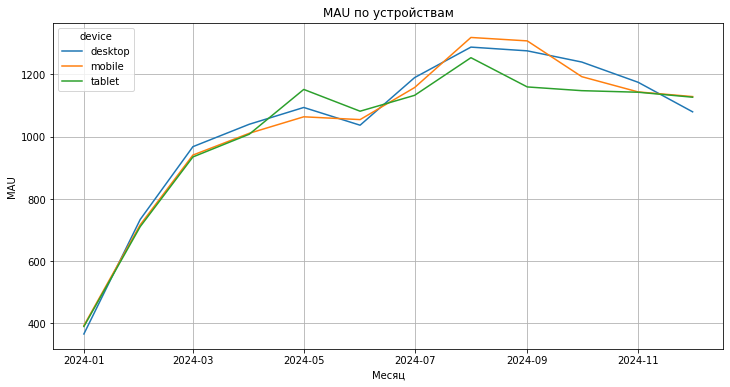

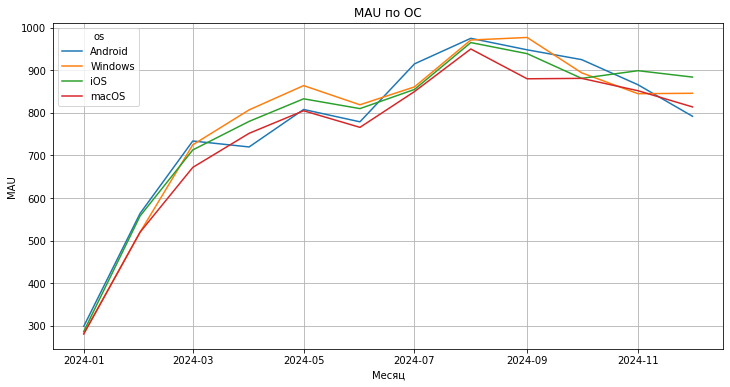

```python
# Агрегируем MAU по устройствам
mau_device = metrics_device.groupby(['month', 'device'])['mau'].sum().reset_index()
# Агрегируем MAU по ОС
mau_os = metrics_device.groupby(['month', 'os'])['mau'].sum().reset_index()

# Построим график MAU по устройствам
plt.figure(figsize=(12,6))
sns.lineplot(data=mau_device, x='month', y='mau', hue='device')
plt.title('MAU по устройствам')
plt.ylabel('MAU')
plt.xlabel('Месяц')
plt.grid()

# Построим график MAU по ОС
plt.figure(figsize=(12,6))
sns.lineplot(data=mau_os, x='month', y='mau', hue='os')
plt.title('MAU по ОС')
plt.ylabel('MAU')
plt.xlabel('Месяц')
plt.grid()
plt.show()
```

Трафик равномерно распределяется между устройствами и ОС, без явных лидеров. Все сегменты росли до августа 2024 года и затем вышли на плато с незначительным снижением к концу года, что указывает на общую тенденцию, а не проблемы конкретной платформы.

- Рассмотрим динамику CR по устройствам, чтобы понять, где пользователям удобнее покупать.

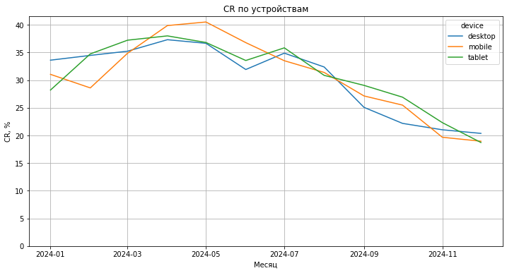

```python
# Агрегируем CR по устройствам
cr_device = metrics_device.groupby(['month', 'device'])[['paying_users', 'mau']].sum().reset_index()
cr_device['cr'] = (cr_device['paying_users'] / cr_device['mau']) * 100

# Построим график MAU по устройствам
plt.figure(figsize=(12,6))
sns.lineplot(data=cr_device, x='month', y='cr', hue='device')
plt.title('CR по устройствам')
plt.ylabel('CR, %')
plt.xlabel('Месяц')
plt.ylim(0)
plt.grid()
plt.show()
```

На всех устройствах наблюдается синхронное и резкое падение конверсии с июня-июля, что подтверждает проблему качества входящего трафика, а не технический сбой конкретной платформы.

В первой половине года Mobile демонстрировал лучший CR ( в мае), однако к концу года эффективность всех платформ сравнялась на низком уровне около 20%.

Параллельное движение графиков `Desktop`, `Mobile` и `Tablet` указывает на то, что интерфейс везде работает стабильно, и критических преград для покупки нет.

- Рассмотрим динамику ARPPU по ОС. Традиционно ожидается, что `iOS` и `macOS` приносят больше дохода, чем `Windows` или `Android`.

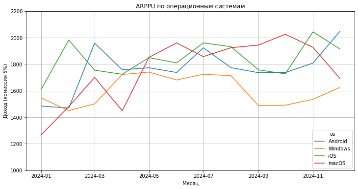

```python
# Агрегируем данные для ARPPU по ОС
arppu_os = metrics_device.groupby(['month', 'os'])[['revenue', 'paying_users']].sum().reset_index()
arppu_os['arppu'] = arppu_os['revenue'] / arppu_os['paying_users']

# Построим график ARPPU по ОС
plt.figure(figsize=(12,6))
sns.lineplot(data=arppu_os, x='month', y='arppu', hue='os')
plt.title('ARPPU по операционным системам')
plt.ylabel('Доход (комиссия 5%)')
plt.xlabel('Месяц')
plt.ylim(1000, 2200)
plt.grid()
plt.show()
```

Динамика ARPPU по всем операционным системам характеризуется высокой волатильностью и отсутствием единого лидера. Единственная стабильная закономерность — небольшое отставание пользователей `Windows`, чей средний доход на платящего пользователя чаще других оказывается в нижней границе графика, хотя и не демонстрирует критического разрыва с остальными платформами.

**Вывод по анализу сегментации по устройствам:**

- Конверсия падает синхронно на всех типах устройств. Это доказывает, что продукт технически стабилен, а общая негативная динамика вызвана внешними факторами.
- Показатели дохода на платящего пользователя по всем ОС находятся в довольно узком диапазоне и часто пересекаются. Явного и стабильного лидера нет. Пользователи Windows показывают чуть более низкий ARPPU в отдельные периоды, но разница не является аномальной.
- Платформа работает одинаково эффективно для всех типов устройств и ОС.

### 4.4 Анализ регионов

Рассмотри динамику метрик в разрезе регионов, чтобы локализовать проблему и определить, является ли негативный тренд следствием плохой работы в конкретных регионах (например, проблем с логистикой или региональным маркетингом) или же он носит фундаментальный характер для всего маркетплейса.

В ходе анализа мы изучим:

- Активность пользователей (MAU): Поймем, в каких регионах сосредоточен основной трафик и где произошел наибольший приток аудитории во втором полугодии.
- Структуру выручки: Определим ключевые регионы по общему доходу.
- Эффективность (CR и ARPPU): С помощью тепловых карт выявим аномальные зоны и проверим синхронность изменения метрик по всей географии присутствия.

```python
# Объединяем события и заказы с данными о регионах
events_geo = events_df.merge(pa_marketplace_users[['user_id', 'region']], on='user_id', how='left')
orders_geo = orders_df.merge(pa_marketplace_users[['user_id', 'region']], on='user_id', how='left')

# Рассчитываем ключевые метрики по сегментам и месяцам
metrics_geo = (events_geo
               .groupby(['region', 'month'], as_index=False)
               .agg(mau=('user_id', 'nunique')))

paying_geo = (orders_geo
                   .groupby(['region', 'month'], as_index=False)
                   .agg(paying_users=('user_id', 'nunique'),
                        total_sales=('total_price', 'sum')))

# Объединяем данные
metrics_geo = metrics_geo.merge(paying_geo, on=['region', 'month'], how='left')

metrics_geo['revenue'] = metrics_geo['total_sales'] * 0.05
metrics_geo['cr'] = metrics_geo['paying_users'] / metrics_geo['mau'] * 100
metrics_geo['arppu'] = metrics_geo['revenue'] / metrics_geo['paying_users']

display(metrics_geo.head().round(2))
```

|  | region | month | mau | paying_users | total_sales | revenue | cr | arppu |
| --- | --- | --- | --- | --- | --- | --- | --- | --- |
| 0 | Другие регионы | 2024-01-01 | 391 | 143 | 4103696.00 | 205184.80 | 36.57 | 1434.86 |
| 1 | Другие регионы | 2024-02-01 | 688 | 261 | 7969620.11 | 398481.01 | 37.94 | 1526.75 |
| 2 | Другие регионы | 2024-03-01 | 904 | 380 | 12346886.37 | 617344.32 | 42.04 | 1624.59 |
| 3 | Другие регионы | 2024-04-01 | 976 | 417 | 13283879.40 | 664193.97 | 42.73 | 1592.79 |
| 4 | Другие регионы | 2024-05-01 | 1070 | 451 | 15069897.40 | 753494.87 | 42.15 | 1670.72 |

|  | region | mau |
| --- | --- | --- |
| 0 | Другие регионы | 11960 |
| 3 | Москва | 9143 |
| 8 | Санкт-Петербург | 5455 |
| 4 | Московская область | 2866 |
| 1 | Екатеринбург | 1658 |

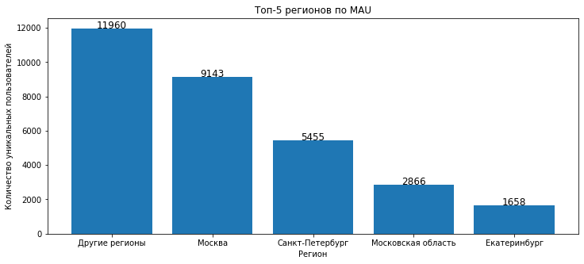

```python
# Топ-5 регионов по MAU
top_regions_mau = (metrics_geo
               .groupby('region', as_index=False)['mau'].sum()
               .sort_values('mau', ascending=False)
               .head(5))

display(top_regions_mau)

# Построим график
plt.figure(figsize=(12, 5))
bars_region = plt.bar(top_regions_mau['region'], top_regions_mau['mau'])

# Перебираем в цикле значения, которые мы только что отобразили
for bar in bars_region:
    height = bar.get_height()
    plt.text(bar.get_x() + bar.get_width() / 2, height, f'{int(height)}', ha='center', fontsize=12)

plt.title('Топ-5 регионов по MAU')
plt.xlabel('Регион')
plt.ylabel('Количество уникальных пользователей')
plt.show()
```

|  | region | revenue |
| --- | --- | --- |
| 0 | Другие регионы | 6.780519e+06 |
| 3 | Москва | 5.376631e+06 |
| 8 | Санкт-Петербург | 3.361395e+06 |
| 4 | Московская область | 1.639988e+06 |
| 1 | Екатеринбург | 1.142688e+06 |

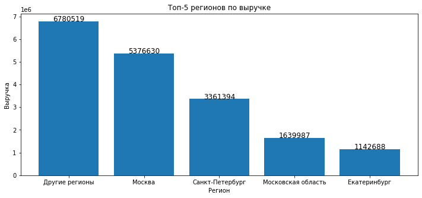

```python
# Топ-5 регионов по выручке
top_regions = (metrics_geo
               .groupby('region', as_index=False)['revenue'].sum()
               .sort_values('revenue', ascending=False)
               .head(5))

display(top_regions)

# Построим график
plt.figure(figsize=(12, 5))
bars_region = plt.bar(top_regions['region'], top_regions['revenue'])

# Перебираем в цикле значения, которые мы только что отобразили
for bar in bars_region:
    height = bar.get_height()
    plt.text(bar.get_x() + bar.get_width() / 2, height, f'{int(height)}', ha='center', fontsize=12)

plt.title('Топ-5 регионов по выручке')
plt.xlabel('Регион')
plt.ylabel('Выручка')
plt.show()
```

Как видно из графиков ТОП-5, основная активность пользователей и основной доход генерируют `Дрругие регионы` и `Москва`, за которыми следует `Санкт-Петербург`. Остальные города вносят заметно меньший вклад в активность и выручку продукта.

- Для детального изучения CR и ARPPU воспользуемся тепловыми картами. Это позволит увидеть динамику по каждому городу без нагромождения линий.

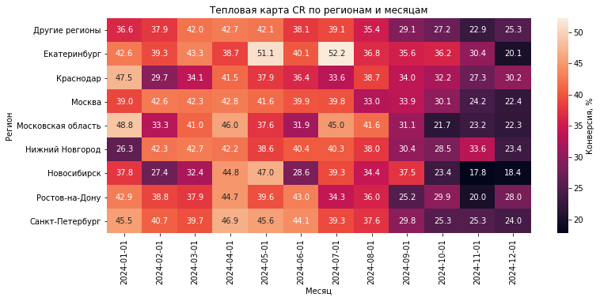

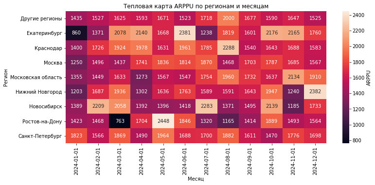

```python
# Преобразуем дату в формат '2024-01-01'
metrics_geo['month'] = metrics_geo['month'].dt.strftime('%Y-%m-%d')

# Подготовка данных для Heatmap
cr_pivot = metrics_geo.pivot(index="region", columns="month", values="cr")
arppu_pivot = metrics_geo.pivot(index="region", columns="month", values="arppu")

# Тепловая карта для CR
plt.figure(figsize=(12, 5))
sns.heatmap(cr_pivot, annot=True, fmt=".1f", cbar_kws={'label': 'Конверсия, %'})
plt.title('Тепловая карта CR по регионам и месяцам')
plt.xlabel('Месяц')
plt.ylabel('Регион')

# Тепловая карта для ARPPU
plt.figure(figsize=(12, 5))
sns.heatmap(arppu_pivot, annot=True, fmt=".0f", cbar_kws={'label': 'ARPPU'})
plt.title('Тепловая карта ARPPU по регионам и месяцам')
plt.xlabel('Месяц')
plt.ylabel('Регион')


plt.show()
```

- На тепловой карте CR отчетливо видно уменьшение конверсии к концу года во всех строках без исключения. Это подтверждает, что снижение конверсии - это общая проблема продукта или трафика, не привязанная к географии.
- `Екатеринбург` демонстрирует нестабильный CR: пик в июле (52.2%) сменился обвалом до 20.1% к декабрю.
- Несмотря на падение конверсии, ARPPU в большинстве регионов остается в рабочем диапазоне 1500–1800. Выделяется `Ростов-на-Дону` и `Екатеринбург`, которые в мае/июне показали аномальный всплеск среднего дохода (2448 и 2381 соответственно), что может указывать на проведение успешных локальных акций.

**Вывод по анализу регионов:**

### 4.5 Анализ воронки

Для поиска слабых мест мы выстроим события в цепочку, отражающую реальный путь пользователя к покупке.

Этапы воронки:

1. Просмотр платформы (`page_view`).
2. Интерес к товару (`product_view`).
3. Намерение купить (`add_to_cart`).
4. Начало оформления (`checkout_start`).
5. Завершение оформления заказа (`checkout_complete`).
6. Оплата (данные по оплате из таблицы `orders_df`).

```python
# Задаем порядок шагов в воронке
funnel_steps = ['page_view', 'product_view', 'add_to_cart', 'checkout_start', 'checkout_complete']

# Фильтруем датасет оставляя только нужные шаги воронки
funnel_df_steps = events_df[events_df['event_type'].isin(funnel_steps)]

# Считаем число уникальных пользователей на каждом шаге
funnel_counts = (
    funnel_df_steps.groupby('event_type')['user_id']
    .nunique()
    .reindex(funnel_steps)
)

# Считаем количество уникальных покупателей из таблицы заказов
paying_users_count = orders_df['user_id'].nunique()

# Собираем таблицу воронки
funnel_df = pd.DataFrame({
    'step':funnel_counts.index.tolist() + ['payment_confirmed'],
    'users':funnel_counts.values.tolist() + [paying_users_count]
})

# Добавляем конверсии и округляем до 1 знака после запятой
funnel_df['conversion_from_first_%'] = funnel_df['users'] / funnel_df['users'][0] * 100

funnel_df['conversion_from_previous_%'] = funnel_df['users'] / funnel_df['users'].shift(1) * 100

display(funnel_df.round(2))
```

|  | step | users | conversion_from_first_% | conversion_from_previous_% |
| --- | --- | --- | --- | --- |
| 0 | page_view | 22098 | 100.00 | NaN |
| 1 | product_view | 22069 | 99.87 | 99.87 |
| 2 | add_to_cart | 20411 | 92.37 | 92.49 |
| 3 | checkout_start | 16769 | 75.88 | 82.16 |
| 4 | checkout_complete | 13897 | 62.89 | 82.87 |
| 5 | payment_confirmed | 8922 | 40.37 | 64.20 |

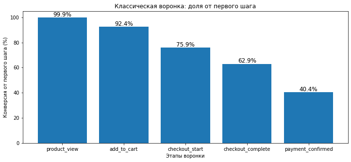

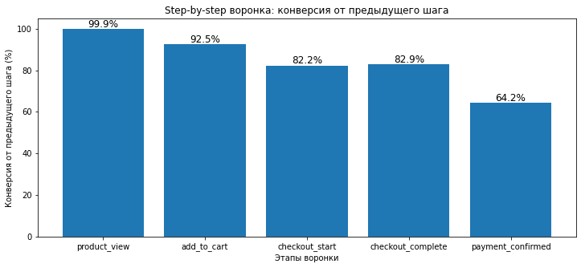

```python
steps = funnel_df['step'][1:]
conversions_classic = funnel_df['conversion_from_first_%'][1:]
conversions_by_step = funnel_df['conversion_from_previous_%'][1:]

# Визуализируем данные классической воронки
plt.figure(figsize=(12, 5))

# Строим barplot
plt.bar(steps,
    conversions_classic)

# Перебираем в цикле значения конверсии, которые мы только что отобразили
for index, value in enumerate(conversions_classic):
    # Для каждого значения добавляем текст на график

    plt.text(index, value + 1, f'{value:.1f}%', ha='center', fontsize=12, color='black')

plt.title('Классическая воронка: доля от первого шага')
plt.ylabel('Конверсия от первого шага (%)')
plt.xlabel('Этапы воронки')

# Визуализируем данные воронки step-by-step
plt.figure(figsize=(12, 5))

# Строим barplot
plt.bar(steps,
        conversions_by_step)

# Перебираем в цикле значения конверсии, которые мы только что отобразили
for index, value in enumerate(conversions_by_step):
    # Для каждого значения добавляем текст на график
    plt.text(index, value + 1, f'{value:.1f}%', ha='center', fontsize=12, color='black')

plt.title('Step-by-step воронка: конверсия от предыдущего шага')
plt.ylabel('Конверсия от предыдущего шага (%)')
plt.xlabel('Этапы воронки')

plt.show()
```

Визуализация классической и пошаговой воронки позволяет сделать следующие выводы:

- Переход от добавления в корзину к началу оформления показывает заметное снижение (82.2%). Суммарно от первого шага до оплаты доходит лишь 40.4% пользователей.
- Самый резкий обрыв воронки происходит на последнем шаге. Конверсия из завершения оформления (`checkout_complete`) в реальную оплату (`payment_confirmed`) составляет всего 64.2%. Это означает, что каждый третий пользователь, полностью заполнивший данные для заказа, в итоге не совершает покупку. Это может быть связано с техническими ошибками, отсутствием удобных способов оплаты или скрытыми комиссиями, которые пользователь видит в самый последний момент.

Общая воронка выявила критическую зону - этап перехода от завершения оформления к подтверждению оплаты. Ранее мы заметили аномальную активность в канале `TikTok`. Чтобы локализовать проблему, мы проведем сравнительный анализ Step-by-step воронки канала `TikTok` с остальными каналами.

```python
# Помечаем пользователей: TikTok или Other
events_channels_df['group'] = events_channels_df['acq_channel'].apply(lambda x: 'TikTok' if x == 'TikTok' else 'Other')
orders_channels_df['group'] = orders_channels_df['acq_channel'].apply(lambda x: 'TikTok' if x == 'TikTok' else 'Other')

# Считаем шаги из логов по группам
funnel_counts = (events_channels_df[events_channels_df['event_type'].isin(funnel_steps)]
    .groupby(['group', 'event_type'])['user_id']
    .nunique()
)

# Считаем оплаты по группам
paying_users = orders_channels_df.groupby('group')['user_id'].nunique()

# Создаем отдельные Series для каждой группы
tiktok_df = funnel_counts['TikTok'].reindex(funnel_steps).tolist() + [paying_users['TikTok']]
other_df = funnel_counts['Other'].reindex(funnel_steps).tolist() + [paying_users['Other']]

# Собираем итоговый результат для вывода
final_table = pd.DataFrame({
    'tiktok': tiktok_df,
    'other': other_df
}, index=funnel_steps + ['payment_confirmed'])

# Считаем Step-by-step конверсию (от предыдущего шага)
group_table = pd.DataFrame()
group_table['tiktok_step_%'] = (final_table['tiktok'] / final_table['tiktok'].shift(1) * 100)
group_table['other_step_%'] = (final_table['other'] / final_table['other'].shift(1) * 100)

display(group_table.round(2).iloc[1:])
```

|  | tiktok_step_% | other_step_% |
| --- | --- | --- |
| product_view | 99.70 | 99.94 |
| add_to_cart | 85.19 | 95.54 |
| checkout_start | 68.14 | 87.40 |
| checkout_complete | 68.41 | 87.21 |
| payment_confirmed | 27.31 | 73.11 |

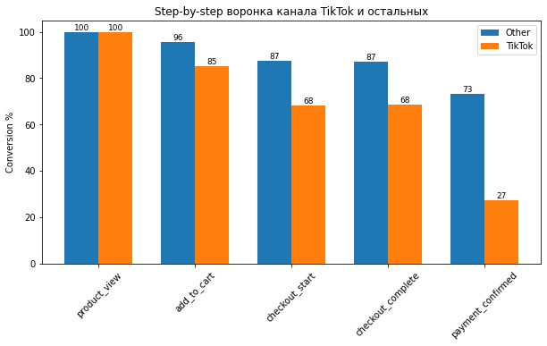

```python
# Берём только нужные строки
plot_df = group_table.iloc[1:].round(2)

x = np.arange(len(plot_df.index))
width = 0.35

plt.figure(figsize=(10, 5))

plt.bar(x - width/2, plot_df['other_step_%'], width, label='Other')
plt.bar(x + width/2, plot_df['tiktok_step_%'], width, label='TikTok')

# Добавляем подписи значений
for i, val in enumerate(plot_df['other_step_%']):
    plt.text(i - width/2, val + 1, f'{val:.0f}',
             ha='center', fontsize=9)

for i, val in enumerate(plot_df['tiktok_step_%']):
    plt.text(i + width/2, val + 1, f'{val:.0f}',
             ha='center', fontsize=9)

plt.xticks(x, plot_df.index, rotation=45)
plt.ylabel('Conversion %')
plt.title('Step-by-step воронка канала TikTok и остальных')
plt.legend()
plt.show()
```

Сравнительный анализ воронки подтвердил, что канал TikTok является определяющим негативный тренд всего маркетплейса:

- Трафик из `TikTok` показывает более низкую эффективность на каждом этапе пути, начиная с добавления в корзину.
- Конверсия из оформления в оплату у `TikTok` составляет всего 27%, что почти в 3 раза ниже, чем у остальных каналов (73%). Столь резкий обвал на финальном шаге указывает на импульсивный характер аудитории, которая легко доходит до чекаута, но массово отказывается от реальных трат.
- Общее падение CR маркетплейса вызвано не поломкой продукта, а изменением структуры трафика в пользу некачественного сегмента из `TikTok`.

**Вывод по анализу воронки:**

Детальное изучение пути пользователя позволило локализовать причину падения общей конверсии маркетплейса:

- Общая воронка показала, что критический отвал происходит на этапе оплаты (конверсия в платеж всего 64.2%).
- Сравнение по каналам выявило, что основной вклад в негативный тренд вносит `TikTok`. Его конверсия из оформления в оплату составляет 27%, в то время как остальные каналы удерживают 73%.
- Тот факт, что другие каналы сохраняют высокую эффективность на этапе платежа, доказывает, что платежная система работает исправно. Проблема кроется в качестве трафика - `TikTok` приводит огромный объем пользователей, которые не собираются совершать покупку.